# NDFS Synthesis Manuscript: Chlorophyll analysis

Models using daily average flow as continuous predictor

Dave Bosworth

November 21, 2023

# Purpose

Explore and analyze the continuous chlorophyll data to be included in the NDFS synthesis manuscript. We will attempt to fit various models to the data set using daily average flow as a continuous predictor which replaces the categorical predictor - flow action period - in the original analysis. These models will only include representative stations for 4 habitat types - upstream (RD22), lower Yolo Bypass (STTD), Cache Slough complex (LIB), and downstream (RVB).

# Global code and functions

```r
# Load packages
library(tidyverse)
library(scales)
library(knitr)
library(mgcv)
library(car)
library(gratia)
library(here)
library(conflicted)

# Source functions
source(here("manuscript_synthesis/src/global_functions.R"))

# Declare package conflict preferences
conflicts_prefer(dplyr::filter(), dplyr::lag())
```

# Import Data

```r
# Define file path for processed data
fp_data <- here("manuscript_synthesis/data/processed")

# Import daily average chlorophyll data
df_chla <- readRDS(file.path(fp_data, "chla_wt_daily_avg_2013-2019.rds")) %>% select(-WaterTemp)

# Import daily average flow data
df_flow <- readRDS(file.path(fp_data, "flow_daily_avg_2013-2019.rds"))
```

# Prepare Data

```r
# Create a vector for the factor order of StationCode
sta_order <- c("RD22", "STTD", "LIB", "RVB")

# We will use LIS flow data as a proxy for STTD
df_flow_c <- df_flow %>% mutate(StationCode = if_else(StationCode == "LIS", "STTD", StationCode))

# Prepare chlorophyll and flow data for exploration and analysis
df_chla_c1 <- df_chla %>%
  # Filter to only include representative stations for 4 habitat types - RD22, STTD, LIB, RVB
  filter(StationCode %in% sta_order) %>%
  # Join flow data to chlorophyll data
  left_join(df_flow_c, by = join_by(StationCode, Date)) %>%
  # Remove all NA flow values
  drop_na(Flow) %>%
  mutate(
    # Scale and log transform chlorophyll values
    Chla_log = log(Chla * 1000),
    # Add Year and DOY variables
    Year = year(Date),
    DOY = yday(Date),
    # Apply factor order to StationCode
    StationCode = factor(StationCode, levels = sta_order),
    # Add a column for Year as a factor for the model
    Year_fct = factor(Year)
  ) %>%
  arrange(StationCode, Date)
```

# Explore sample counts by Station

```r
df_chla_c1 %>%
  summarize(
    min_date = min(Date),
    max_date = max(Date),
    num_samples = n(),
    .by = c(StationCode, Year)
  ) %>%
  arrange(StationCode, Year) %>%
  kable()
```

| StationCode | Year | min_date | max_date | num_samples |
| --- | --- | --- | --- | --- |
| RD22 | 2014 | 2014-09-30 | 2014-11-08 | 40 |
| RD22 | 2015 | 2015-07-24 | 2015-11-10 | 110 |
| RD22 | 2016 | 2016-06-23 | 2016-09-16 | 86 |
| RD22 | 2017 | 2017-07-14 | 2017-11-03 | 113 |
| RD22 | 2018 | 2018-07-13 | 2018-11-11 | 122 |
| RD22 | 2019 | 2019-07-11 | 2019-11-06 | 119 |
| STTD | 2013 | 2013-08-15 | 2013-11-04 | 78 |
| STTD | 2014 | 2014-07-25 | 2014-10-19 | 87 |
| STTD | 2015 | 2015-07-27 | 2015-11-16 | 108 |
| STTD | 2016 | 2016-06-23 | 2016-09-16 | 83 |
| STTD | 2017 | 2017-07-14 | 2017-09-25 | 56 |
| STTD | 2018 | 2018-07-20 | 2018-10-11 | 84 |
| STTD | 2019 | 2019-07-26 | 2019-11-06 | 100 |
| LIB | 2014 | 2014-10-01 | 2014-11-08 | 36 |
| LIB | 2015 | 2015-07-06 | 2015-11-16 | 125 |
| LIB | 2016 | 2016-05-29 | 2016-09-16 | 101 |
| LIB | 2017 | 2017-07-14 | 2017-11-02 | 96 |
| LIB | 2018 | 2018-08-14 | 2018-10-31 | 36 |
| LIB | 2019 | 2019-07-11 | 2019-10-25 | 31 |
| RVB | 2013 | 2013-07-07 | 2013-11-17 | 134 |
| RVB | 2014 | 2014-07-25 | 2014-11-08 | 105 |
| RVB | 2015 | 2015-07-06 | 2015-11-16 | 134 |
| RVB | 2016 | 2016-05-29 | 2016-09-16 | 80 |
| RVB | 2017 | 2017-07-14 | 2017-11-03 | 113 |
| RVB | 2018 | 2018-07-13 | 2018-11-11 | 122 |
| RVB | 2019 | 2019-07-11 | 2019-11-06 | 102 |

Looking at the sample counts and date ranges, we’ll only include years 2015-2019 for the analysis.

```r
df_chla_c2 <- df_chla_c1 %>%
  filter(Year %in% 2015:2019) %>%
  mutate(Year_fct = fct_drop(Year_fct))

# Create another dataframe that has up to 3 lag variables for chlorophyll to be
  # used in the linear models
df_chla_c2_lag <- df_chla_c2 %>%
  # Fill in missing days for each StationCode-Year combination
  group_by(StationCode, Year) %>%
  complete(Date = seq.Date(min(Date), max(Date), by = "1 day")) %>%
  # Create lag variables of scaled log transformed chlorophyll values
  mutate(
    lag1 = lag(Chla_log),
    lag2 = lag(Chla_log, 2),
    lag3 = lag(Chla_log, 3)
  ) %>%
  ungroup()
```

# Plots

Let’s explore the data with some plots. First, lets plot the data in scatterplots of chlorophyll and flow facetted by Station and grouping all years together.

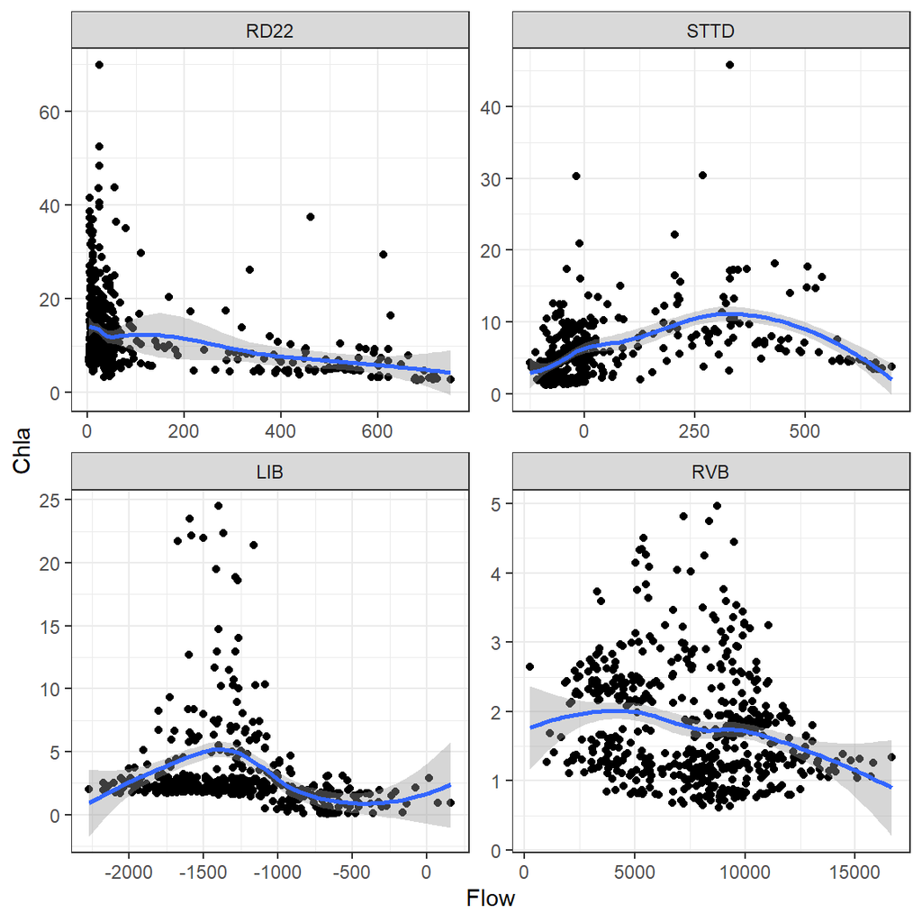

```r
df_chla_c2 %>%
  ggplot(aes(x = Flow, y = Chla)) +
  geom_point() +
  geom_smooth(formula = "y ~ x") +
  facet_wrap(vars(StationCode), scales = "free") +
  theme_bw()
```

At first glance, I’m not sure how well flow is going to be able to predict chlorophyll concentrations. At the furthest upstream station - RD22 - chlorophyll appears to be highest at the lowest flows, but the variation is at its maximum at the lowest flows. There may be some dilution effect going on here at the higher flows. At STTD, there does seem to be a modest increase in chlorophyll concentrations at the mid-range flows. This pattern is even more obvious at LIB. There appears to be no effect of flow on chlorophyll at RVB, but the range of chlorophyll concentrations is narrow at this station (between 0 and 5).

Let’s break these scatterplots apart by year to see how these patterns vary annually.

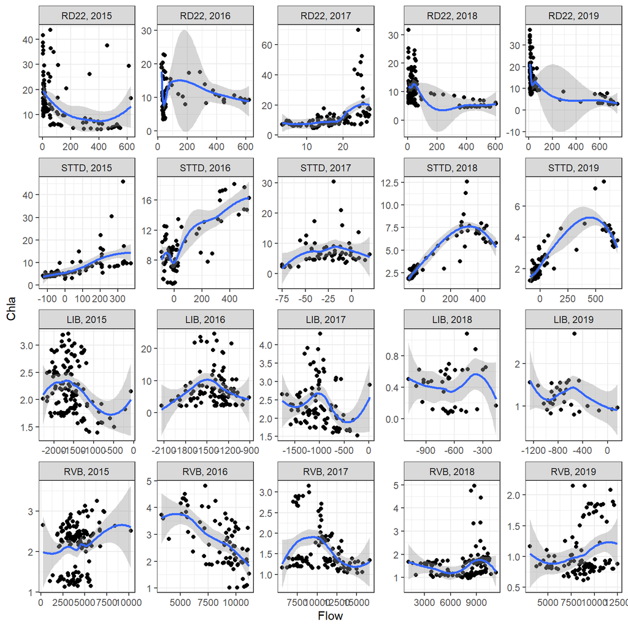

```r
df_chla_c2 %>%
  ggplot(aes(x = Flow, y = Chla)) +
  geom_point() +
  geom_smooth(formula = "y ~ x") +
  facet_wrap(
    vars(StationCode, Year),
    ncol = 5,
    scales = "free",
    labeller = labeller(.multi_line = FALSE)
  ) +
  theme_bw()
```

The patterns appear to vary annually at each station, which may justify using a 3-way interaction.

# GAM Model with 3-way interactions

First, we will attempt to fit a generalized additive model (GAM) to the data set to help account for seasonality in the data. We’ll try running a GAM using a three-way interaction between Year, Daily Average Flow, and Station, and a smooth term for day of year to account for seasonality. Initially, we’ll run the GAM without accounting for serial autocorrelation.

## Initial Model

```r
m_gam3 <- gam(
  Chla_log ~ Year_fct * Flow * StationCode + s(DOY),
  data = df_chla_c2,
  method = "REML"
)
```

Lets look at the model summary and diagnostics:

```r
summary(m_gam3)
```

```
##
## Family: gaussian
## Link function: identity
##
## Formula:
## Chla_log ~ Year_fct * Flow * StationCode + s(DOY)
##
## Parametric coefficients:
##                                     Estimate Std. Error t value Pr(>|t|)
## (Intercept)                        9.745e+00  4.283e-02 227.546  < 2e-16 ***
## Year_fct2016                      -8.341e-01  6.570e-02 -12.696  < 2e-16 ***
## Year_fct2017                      -9.211e-01  9.375e-02  -9.825  < 2e-16 ***
## Year_fct2018                      -3.811e-01  5.645e-02  -6.750 1.96e-11 ***
## Year_fct2019                      -1.553e-01  5.595e-02  -2.775  0.00557 **
## Flow                              -1.869e-03  1.825e-04 -10.240  < 2e-16 ***
## StationCodeSTTD                   -1.075e+00  5.393e-02 -19.926  < 2e-16 ***
## StationCodeLIB                    -2.137e+00  1.437e-01 -14.875  < 2e-16 ***
## StationCodeRVB                    -2.195e+00  1.005e-01 -21.842  < 2e-16 ***
## Year_fct2016:Flow                  2.209e-03  2.990e-04   7.388 2.24e-13 ***
## Year_fct2017:Flow                  2.950e-02  4.852e-03   6.080 1.45e-09 ***
## Year_fct2018:Flow                  4.676e-04  2.482e-04   1.884  0.05977 .
## Year_fct2019:Flow                 -7.187e-05  2.176e-04  -0.330  0.74126
## Year_fct2016:StationCodeSTTD       1.082e+00  8.210e-02  13.181  < 2e-16 ***
## Year_fct2017:StationCodeSTTD       1.048e+00  1.242e-01   8.441  < 2e-16 ***
## Year_fct2018:StationCodeSTTD      -2.895e-01  7.742e-02  -3.739  0.00019 ***
## Year_fct2019:StationCodeSTTD      -8.838e-01  7.574e-02 -11.668  < 2e-16 ***
## Year_fct2016:StationCodeLIB        2.203e+00  2.546e-01   8.652  < 2e-16 ***
## Year_fct2017:StationCodeLIB        9.576e-01  1.991e-01   4.810 1.63e-06 ***
## Year_fct2018:StationCodeLIB       -1.551e+00  2.409e-01  -6.436 1.55e-10 ***
## Year_fct2019:StationCodeLIB       -3.510e-01  2.135e-01  -1.644  0.10033
## Year_fct2016:StationCodeRVB        1.212e+00  2.309e-01   5.248 1.71e-07 ***
## Year_fct2017:StationCodeRVB        9.736e-01  2.001e-01   4.866 1.23e-06 ***
## Year_fct2018:StationCodeRVB        1.274e-01  1.557e-01   0.818  0.41349
## Year_fct2019:StationCodeRVB       -8.231e-01  1.848e-01  -4.454 8.94e-06 ***
## Flow:StationCodeSTTD               4.740e-03  2.936e-04  16.147  < 2e-16 ***
## Flow:StationCodeLIB                1.812e-03  2.039e-04   8.883  < 2e-16 ***
## Flow:StationCodeRVB                1.891e-03  1.838e-04  10.290  < 2e-16 ***
## Year_fct2016:Flow:StationCodeSTTD -3.737e-03  4.362e-04  -8.566  < 2e-16 ***
## Year_fct2017:Flow:StationCodeSTTD -2.723e-02  5.249e-03  -5.187 2.37e-07 ***
## Year_fct2018:Flow:StationCodeSTTD -7.936e-04  3.882e-04  -2.044  0.04105 *
## Year_fct2019:Flow:StationCodeSTTD -1.449e-03  3.440e-04  -4.213 2.64e-05 ***
## Year_fct2016:Flow:StationCodeLIB  -1.816e-03  3.421e-04  -5.307 1.25e-07 ***
## Year_fct2017:Flow:StationCodeLIB  -2.955e-02  4.855e-03  -6.087 1.39e-09 ***
## Year_fct2018:Flow:StationCodeLIB  -6.475e-04  3.801e-04  -1.703  0.08865 .
## Year_fct2019:Flow:StationCodeLIB   2.046e-04  3.072e-04   0.666  0.50555
## Year_fct2016:Flow:StationCodeRVB  -2.268e-03  3.003e-04  -7.551 6.70e-14 ***
## Year_fct2017:Flow:StationCodeRVB  -2.955e-02  4.852e-03  -6.089 1.37e-09 ***
## Year_fct2018:Flow:StationCodeRVB  -4.848e-04  2.495e-04  -1.943  0.05219 .
## Year_fct2019:Flow:StationCodeRVB   9.204e-05  2.197e-04   0.419  0.67527
## ---
## Signif. codes:  0 '***' 0.001 '**' 0.01 '*' 0.05 '.' 0.1 ' ' 1
##
## Approximate significance of smooth terms:
##          edf Ref.df     F p-value
## s(DOY) 7.487  8.411 40.88  <2e-16 ***
## ---
## Signif. codes:  0 '***' 0.001 '**' 0.01 '*' 0.05 '.' 0.1 ' ' 1
##
## R-sq.(adj) =  0.875   Deviance explained = 87.8%
## -REML = 898.16  Scale est. = 0.12072   n = 1921
```

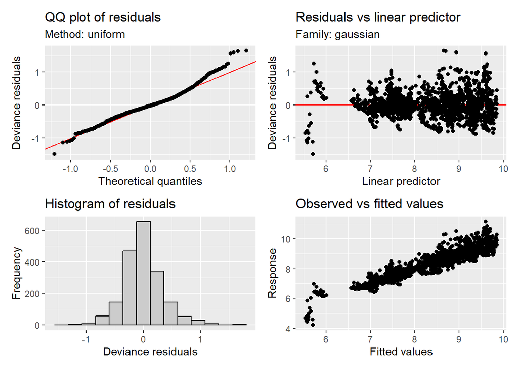

```r
appraise(m_gam3)
```

```r
shapiro.test(residuals(m_gam3))
```

```
##
##  Shapiro-Wilk normality test
##
## data:  residuals(m_gam3)
## W = 0.97102, p-value < 2.2e-16
```

```r
k.check(m_gam3)
```

```
##        k'      edf   k-index p-value
## s(DOY)  9 7.486841 0.9418805   0.005
```

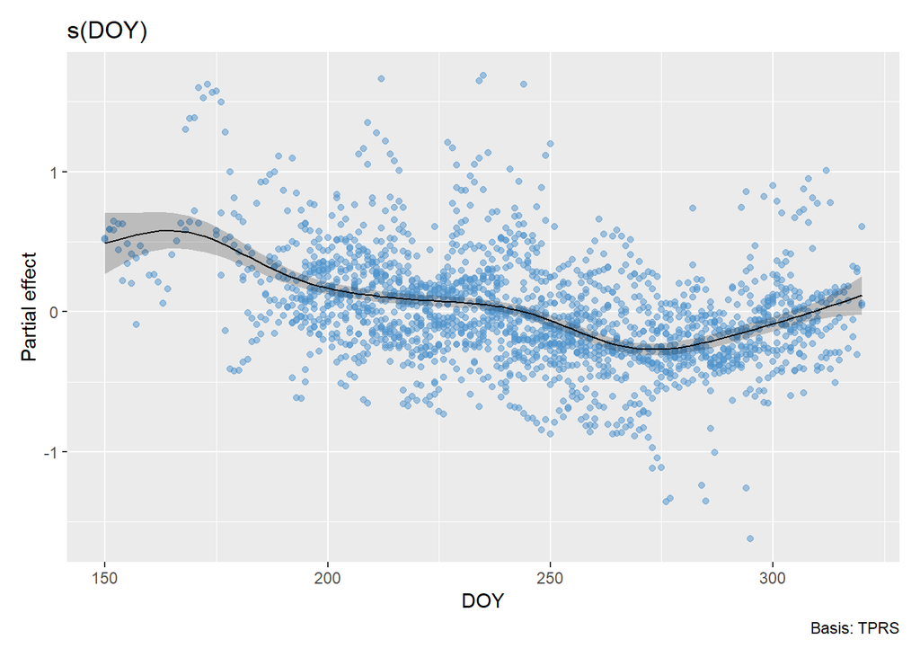

```r
draw(m_gam3, select = 1, residuals = TRUE, rug = FALSE)
```

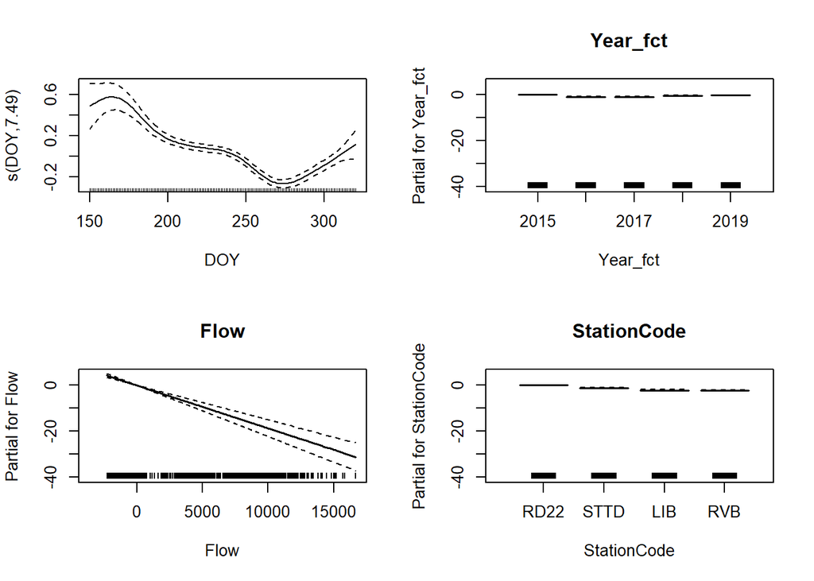

```r
plot(m_gam3, pages = 1, all.terms = TRUE)
```

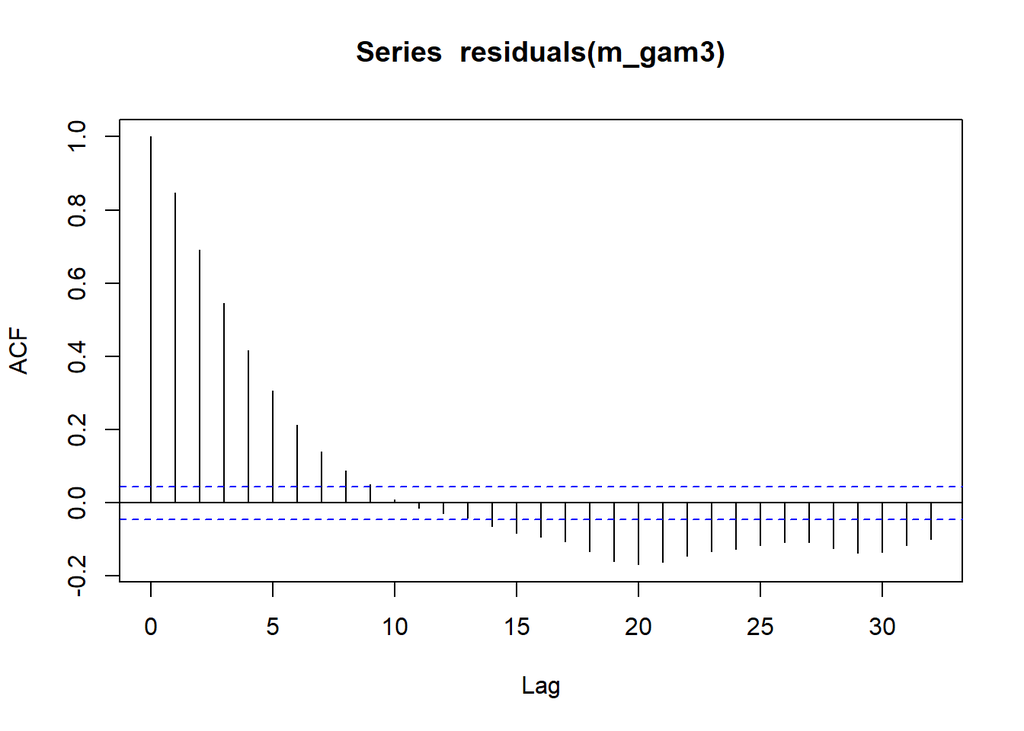

```r
acf(residuals(m_gam3))
```

```r
Box.test(residuals(m_gam3), lag = 20, type = 'Ljung-Box')
```

```
##
##  Box-Ljung test
##
## data:  residuals(m_gam3)
## X-squared = 3735.8, df = 20, p-value < 2.2e-16
```

## Model with k = 5

The model definitely has residual autocorrelation as indicated by the ACF plot and the Box-Ljung test. Even though the p-value for the k-check is less than 0.05, the smooth term for day of year appears to be overfitted. Let’s try a smaller k-value for the smooth first, then lets try to address the residual autocorrelation.

```r
m_gam3_k5 <- gam(
  Chla_log ~ Year_fct * Flow * StationCode + s(DOY, k = 5),
  data = df_chla_c2,
  method = "REML"
)

summary(m_gam3_k5)
```

```
##
## Family: gaussian
## Link function: identity
##
## Formula:
## Chla_log ~ Year_fct * Flow * StationCode + s(DOY, k = 5)
##
## Parametric coefficients:
##                                     Estimate Std. Error t value Pr(>|t|)
## (Intercept)                        9.733e+00  4.260e-02 228.453  < 2e-16 ***
## Year_fct2016                      -7.901e-01  6.461e-02 -12.229  < 2e-16 ***
## Year_fct2017                      -9.026e-01  9.409e-02  -9.593  < 2e-16 ***
## Year_fct2018                      -3.787e-01  5.676e-02  -6.672 3.32e-11 ***
## Year_fct2019                      -1.526e-01  5.625e-02  -2.714 0.006711 **
## Flow                              -1.808e-03  1.803e-04 -10.029  < 2e-16 ***
## StationCodeSTTD                   -1.069e+00  5.408e-02 -19.760  < 2e-16 ***
## StationCodeLIB                    -2.132e+00  1.438e-01 -14.828  < 2e-16 ***
## StationCodeRVB                    -2.191e+00  1.009e-01 -21.726  < 2e-16 ***
## Year_fct2016:Flow                  2.031e-03  2.952e-04   6.881 8.06e-12 ***
## Year_fct2017:Flow                  2.882e-02  4.852e-03   5.941 3.37e-09 ***
## Year_fct2018:Flow                  4.505e-04  2.496e-04   1.805 0.071304 .
## Year_fct2019:Flow                 -9.132e-05  2.188e-04  -0.417 0.676427
## Year_fct2016:StationCodeSTTD       1.069e+00  8.243e-02  12.964  < 2e-16 ***
## Year_fct2017:StationCodeSTTD       1.036e+00  1.248e-01   8.298  < 2e-16 ***
## Year_fct2018:StationCodeSTTD      -2.965e-01  7.785e-02  -3.809 0.000144 ***
## Year_fct2019:StationCodeSTTD      -8.854e-01  7.604e-02 -11.644  < 2e-16 ***
## Year_fct2016:StationCodeLIB        2.201e+00  2.555e-01   8.615  < 2e-16 ***
## Year_fct2017:StationCodeLIB        9.597e-01  1.992e-01   4.817 1.57e-06 ***
## Year_fct2018:StationCodeLIB       -1.511e+00  2.415e-01  -6.257 4.84e-10 ***
## Year_fct2019:StationCodeLIB       -3.715e-01  2.144e-01  -1.733 0.083277 .
## Year_fct2016:StationCodeRVB        1.158e+00  2.306e-01   5.021 5.62e-07 ***
## Year_fct2017:StationCodeRVB        9.786e-01  1.999e-01   4.895 1.07e-06 ***
## Year_fct2018:StationCodeRVB        1.267e-01  1.564e-01   0.810 0.417994
## Year_fct2019:StationCodeRVB       -8.344e-01  1.853e-01  -4.504 7.09e-06 ***
## Flow:StationCodeSTTD               4.756e-03  2.952e-04  16.111  < 2e-16 ***
## Flow:StationCodeLIB                1.749e-03  2.024e-04   8.641  < 2e-16 ***
## Flow:StationCodeRVB                1.832e-03  1.816e-04  10.087  < 2e-16 ***
## Year_fct2016:Flow:StationCodeSTTD -3.760e-03  4.388e-04  -8.570  < 2e-16 ***
## Year_fct2017:Flow:StationCodeSTTD -2.633e-02  5.239e-03  -5.026 5.48e-07 ***
## Year_fct2018:Flow:StationCodeSTTD -8.012e-04  3.906e-04  -2.051 0.040386 *
## Year_fct2019:Flow:StationCodeSTTD -1.475e-03  3.460e-04  -4.262 2.13e-05 ***
## Year_fct2016:Flow:StationCodeLIB  -1.620e-03  3.392e-04  -4.776 1.93e-06 ***
## Year_fct2017:Flow:StationCodeLIB  -2.885e-02  4.853e-03  -5.946 3.27e-09 ***
## Year_fct2018:Flow:StationCodeLIB  -5.940e-04  3.818e-04  -1.556 0.119930
## Year_fct2019:Flow:StationCodeLIB   2.056e-04  3.088e-04   0.666 0.505630
## Year_fct2016:Flow:StationCodeRVB  -2.087e-03  2.962e-04  -7.045 2.59e-12 ***
## Year_fct2017:Flow:StationCodeRVB  -2.887e-02  4.852e-03  -5.950 3.19e-09 ***
## Year_fct2018:Flow:StationCodeRVB  -4.685e-04  2.510e-04  -1.867 0.062082 .
## Year_fct2019:Flow:StationCodeRVB   1.118e-04  2.207e-04   0.506 0.612687
## ---
## Signif. codes:  0 '***' 0.001 '**' 0.01 '*' 0.05 '.' 0.1 ' ' 1
##
## Approximate significance of smooth terms:
##          edf Ref.df     F p-value
## s(DOY) 3.897  3.994 82.03  <2e-16 ***
## ---
## Signif. codes:  0 '***' 0.001 '**' 0.01 '*' 0.05 '.' 0.1 ' ' 1
##
## R-sq.(adj) =  0.874   Deviance explained = 87.7%
## -REML = 905.16  Scale est. = 0.12223   n = 1921
```

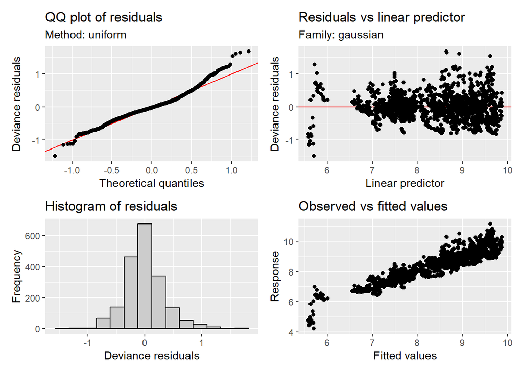

```r
appraise(m_gam3_k5)
```

```r
shapiro.test(residuals(m_gam3_k5))
```

```
##
##  Shapiro-Wilk normality test
##
## data:  residuals(m_gam3_k5)
## W = 0.96838, p-value < 2.2e-16
```

```r
k.check(m_gam3_k5)
```

```
##        k'      edf   k-index p-value
## s(DOY)  4 3.897303 0.9289271       0
```

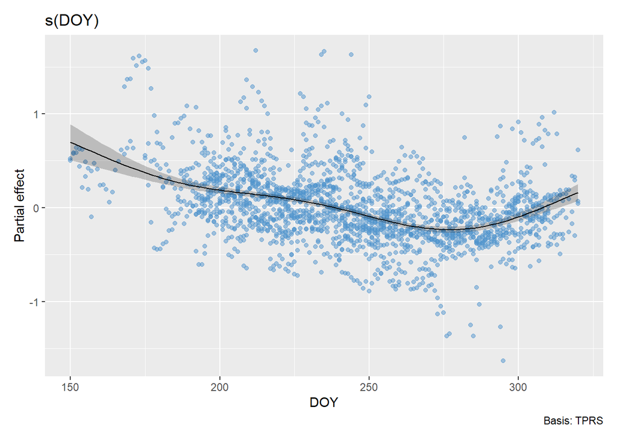

```r
draw(m_gam3_k5, select = 1, residuals = TRUE, rug = FALSE)
```

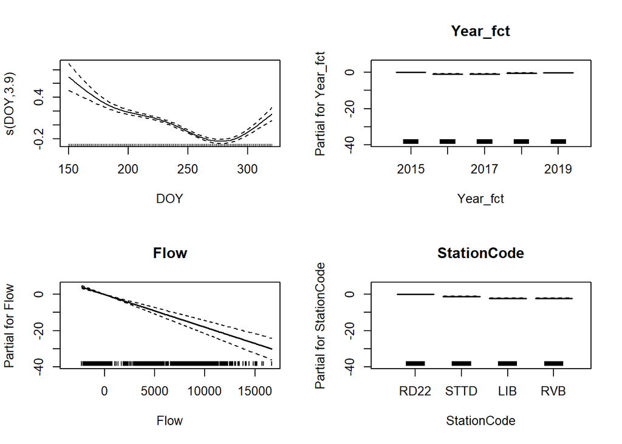

```r
plot(m_gam3_k5, pages = 1, all.terms = TRUE)
```

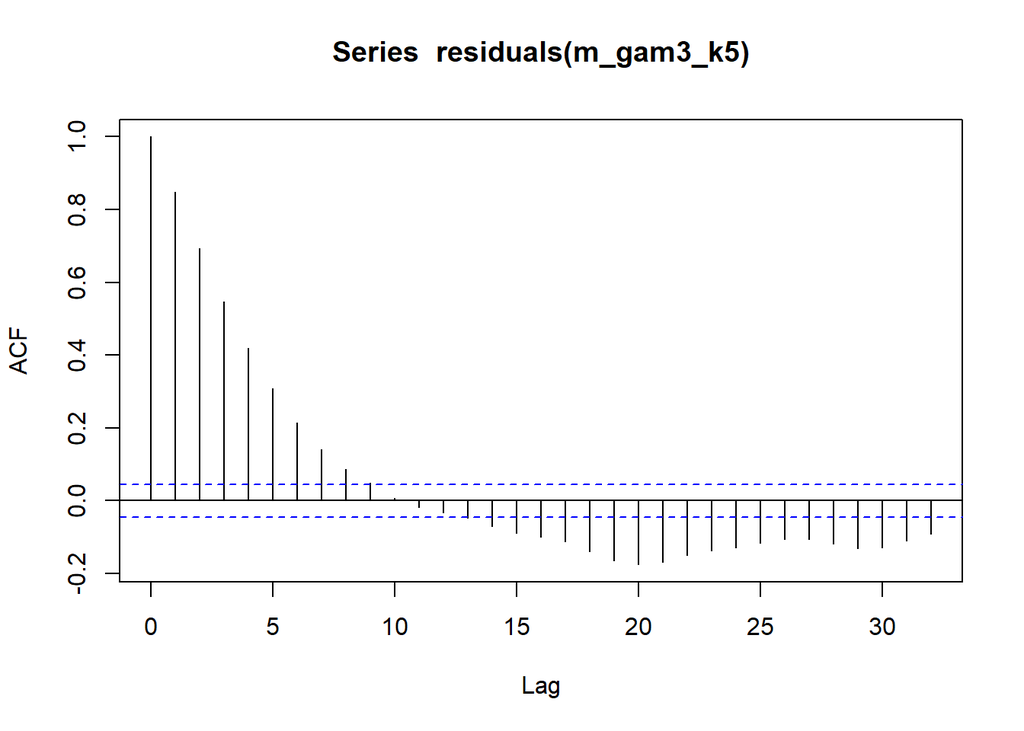

```r
acf(residuals(m_gam3_k5))
```

```r
Box.test(residuals(m_gam3_k5), lag = 20, type = 'Ljung-Box')
```

```
##
##  Box-Ljung test
##
## data:  residuals(m_gam3_k5)
## X-squared = 3775.8, df = 20, p-value < 2.2e-16
```

Changing the k-value to 5 seems to help reduce the “wiggliness” of the smooth term for DOY, but the p-value for the k-check is still less than 0.05. Despite this, lets proceed with a k-value of 5.

## Model with AR() correlation structure

Now, we’ll try to deal with the residual autocorrelation. We’ll run AR(1), AR(2), AR(3), and AR(4) models and compare them using AIC.

```r
# Define model formula as an object
f_gam3 <- as.formula("Chla_log ~ Year_fct * Flow * StationCode + s(DOY, k = 5)")

# Fit original model with k = 5 and three successive AR(p) models
m_gamm3 <- gamm(
  f_gam3,
  data = df_chla_c2,
  method = "REML"
)

m_gamm3_ar1 <- gamm(
  f_gam3,
  data = df_chla_c2,
  correlation = corARMA(form = ~ 1|Year_fct/StationCode, p = 1), # grouped by Year_fct and StationCode
  method = "REML"
)

m_gamm3_ar2 <- gamm(
  f_gam3,
  data = df_chla_c2,
  correlation = corARMA(form = ~ 1|Year_fct/StationCode, p = 2),
  method = "REML"
)

m_gamm3_ar3 <- gamm(
  f_gam3,
  data = df_chla_c2,
  correlation = corARMA(form = ~ 1|Year_fct/StationCode, p = 3),
  method = "REML"
)

m_gamm3_ar4 <- gamm(
  f_gam3,
  data = df_chla_c2,
  correlation = corARMA(form = ~ 1|Year_fct/StationCode, p = 4),
  method = "REML"
)

# Compare models
anova(
  m_gamm3$lme,
  m_gamm3_ar1$lme,
  m_gamm3_ar2$lme,
  m_gamm3_ar3$lme,
  m_gamm3_ar4$lme
)
```

```
##                 Model df       AIC       BIC    logLik   Test   L.Ratio p-value
## m_gamm3$lme         1 43 1896.3152 2134.4933 -905.1576
## m_gamm3_ar1$lme     2 44 -761.4514 -517.7342  424.7257 1 vs 2 2659.7665  <.0001
## m_gamm3_ar2$lme     3 45 -761.1459 -511.8897  425.5730 2 vs 3    1.6945  0.1930
## m_gamm3_ar3$lme     4 46 -762.6776 -507.8824  427.3388 3 vs 4    3.5317  0.0602
## m_gamm3_ar4$lme     5 47 -760.6894 -500.3552  427.3447 4 vs 5    0.0118  0.9133
```

It looks like the AR(3) model has the best fit according to the AIC values. However, BIC prefers the AR(1) model. Let’s take a closer look at the AR(1) model.

## AR(1) Model

```r
# Pull out the residuals and the GAM model
resid_gamm3_ar1 <- residuals(m_gamm3_ar1$lme, type = "normalized")
m_gamm3_ar1_gam <- m_gamm3_ar1$gam

summary(m_gamm3_ar1_gam)
```

```
##
## Family: gaussian
## Link function: identity
##
## Formula:
## Chla_log ~ Year_fct * Flow * StationCode + s(DOY, k = 5)
##
## Parametric coefficients:
##                                     Estimate Std. Error t value Pr(>|t|)
## (Intercept)                        9.518e+00  2.152e-01  44.217  < 2e-16 ***
## Year_fct2016                      -6.228e-01  3.255e-01  -1.913  0.05587 .
## Year_fct2017                      -4.890e-01  3.314e-01  -1.476  0.14016
## Year_fct2018                      -2.959e-01  2.987e-01  -0.991  0.32201
## Year_fct2019                      -3.006e-02  2.998e-01  -0.100  0.92015
## Flow                              -6.681e-04  2.914e-04  -2.293  0.02197 *
## StationCodeSTTD                   -8.105e-01  3.024e-01  -2.680  0.00743 **
## StationCodeLIB                    -1.712e+00  3.119e-01  -5.490 4.57e-08 ***
## StationCodeRVB                    -1.847e+00  2.957e-01  -6.247 5.17e-10 ***
## Year_fct2016:Flow                  1.008e-03  5.864e-04   1.719  0.08578 .
## Year_fct2017:Flow                  1.318e-02  8.063e-03   1.635  0.10232
## Year_fct2018:Flow                  6.137e-05  5.312e-04   0.116  0.90802
## Year_fct2019:Flow                 -3.428e-04  4.481e-04  -0.765  0.44432
## Year_fct2016:StationCodeSTTD       9.596e-01  4.533e-01   2.117  0.03439 *
## Year_fct2017:StationCodeSTTD       3.666e-01  4.833e-01   0.758  0.44827
## Year_fct2018:StationCodeSTTD      -4.601e-01  4.375e-01  -1.052  0.29313
## Year_fct2019:StationCodeSTTD      -1.078e+00  4.296e-01  -2.508  0.01221 *
## Year_fct2016:StationCodeLIB        1.892e+00  4.690e-01   4.035 5.69e-05 ***
## Year_fct2017:StationCodeLIB        5.850e-01  4.679e-01   1.250  0.21127
## Year_fct2018:StationCodeLIB       -1.588e+00  4.994e-01  -3.181  0.00149 **
## Year_fct2019:StationCodeLIB       -7.228e-01  5.097e-01  -1.418  0.15634
## Year_fct2016:StationCodeRVB        9.792e-01  4.745e-01   2.064  0.03919 *
## Year_fct2017:StationCodeRVB        2.970e-01  4.728e-01   0.628  0.52996
## Year_fct2018:StationCodeRVB        1.256e-02  4.359e-01   0.029  0.97701
## Year_fct2019:StationCodeRVB       -5.866e-01  4.441e-01  -1.321  0.18667
## Flow:StationCodeSTTD               1.563e-03  5.696e-04   2.744  0.00614 **
## Flow:StationCodeLIB                7.331e-04  3.001e-04   2.443  0.01467 *
## Flow:StationCodeRVB                6.702e-04  2.917e-04   2.298  0.02167 *
## Year_fct2016:Flow:StationCodeSTTD -1.668e-03  9.315e-04  -1.791  0.07345 .
## Year_fct2017:Flow:StationCodeSTTD -7.118e-03  8.237e-03  -0.864  0.38762
## Year_fct2018:Flow:StationCodeSTTD  4.618e-04  8.986e-04   0.514  0.60738
## Year_fct2019:Flow:StationCodeSTTD  7.969e-04  7.567e-04   1.053  0.29244
## Year_fct2016:Flow:StationCodeLIB  -7.348e-04  5.979e-04  -1.229  0.21925
## Year_fct2017:Flow:StationCodeLIB  -1.306e-02  8.064e-03  -1.620  0.10537
## Year_fct2018:Flow:StationCodeLIB   1.411e-04  5.571e-04   0.253  0.80007
## Year_fct2019:Flow:StationCodeLIB   3.178e-04  4.756e-04   0.668  0.50408
## Year_fct2016:Flow:StationCodeRVB  -1.024e-03  5.868e-04  -1.746  0.08101 .
## Year_fct2017:Flow:StationCodeRVB  -1.319e-02  8.063e-03  -1.635  0.10212
## Year_fct2018:Flow:StationCodeRVB  -7.120e-05  5.316e-04  -0.134  0.89346
## Year_fct2019:Flow:StationCodeRVB   3.206e-04  4.485e-04   0.715  0.47479
## ---
## Signif. codes:  0 '***' 0.001 '**' 0.01 '*' 0.05 '.' 0.1 ' ' 1
##
## Approximate significance of smooth terms:
##          edf Ref.df     F p-value
## s(DOY) 3.745  3.745 9.993 5.3e-07 ***
## ---
## Signif. codes:  0 '***' 0.001 '**' 0.01 '*' 0.05 '.' 0.1 ' ' 1
##
## R-sq.(adj) =   0.82
##   Scale est. = 0.22667   n = 1921
```

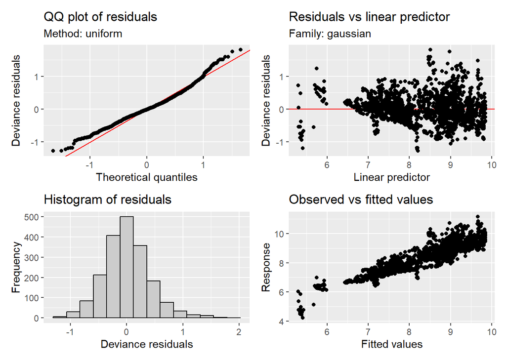

```r
appraise(m_gamm3_ar1_gam)
```

```r
shapiro.test(resid_gamm3_ar1)
```

```
##
##  Shapiro-Wilk normality test
##
## data:  resid_gamm3_ar1
## W = 0.84032, p-value < 2.2e-16
```

```r
k.check(m_gamm3_ar1_gam)
```

```
##        k'     edf   k-index p-value
## s(DOY)  4 3.74514 0.8115987       0
```

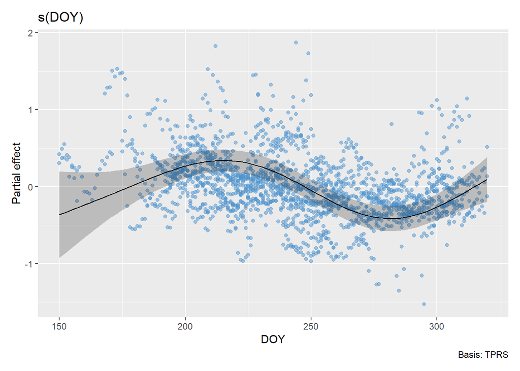

```r
draw(m_gamm3_ar1_gam, select = 1, residuals = TRUE, rug = FALSE)
```

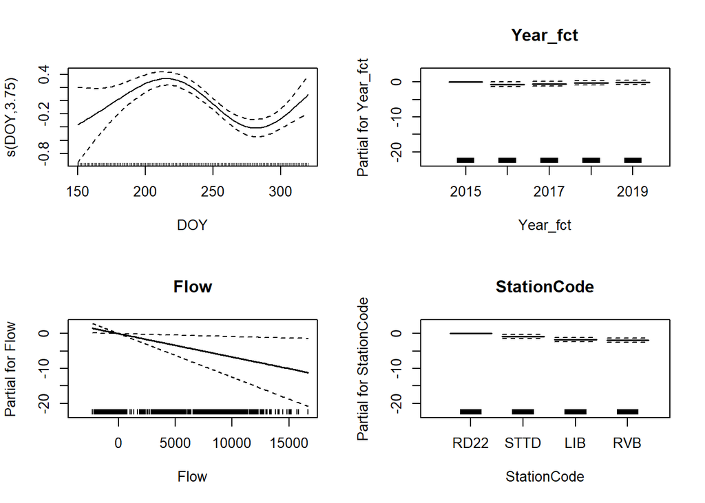

```r
plot(m_gamm3_ar1_gam, pages = 1, all.terms = TRUE)
```

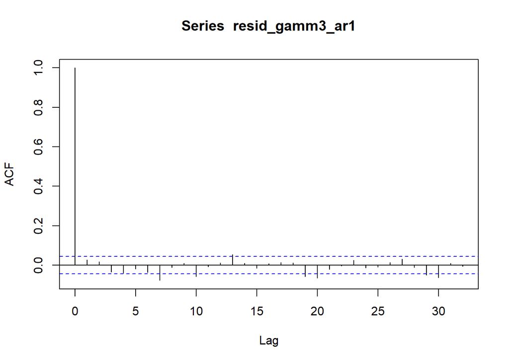

```r
acf(resid_gamm3_ar1)
```

```r
Box.test(resid_gamm3_ar1, lag = 20, type = 'Ljung-Box')
```

```
##
##  Box-Ljung test
##
## data:  resid_gamm3_ar1
## X-squared = 50.995, df = 20, p-value = 0.0001593
```

The AR(1) model has much less residual autocorrelation, and the diagnostics plots look okay. Let’s take a closer look at how the back-transformed fitted values from the model match the observed values.

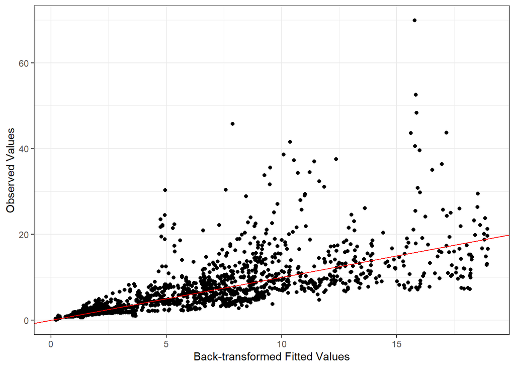

```r
df_gamm3_ar1_fit <- df_chla_c2 %>%
  fitted_values(m_gamm3_ar1_gam, data = .) %>%
  mutate(fitted_bt = exp(fitted) / 1000)

plt_gamm3_ar1_obs_fit <- df_gamm3_ar1_fit %>%
  ggplot(aes(x = fitted_bt, y = Chla)) +
  geom_point() +
  geom_abline(slope = 1, intercept = 0, color = "red") +
  theme_bw() +
  labs(
    x = "Back-transformed Fitted Values",
    y = "Observed Values"
  )

plt_gamm3_ar1_obs_fit
```

Let’s look at each Station-Year combination separately.

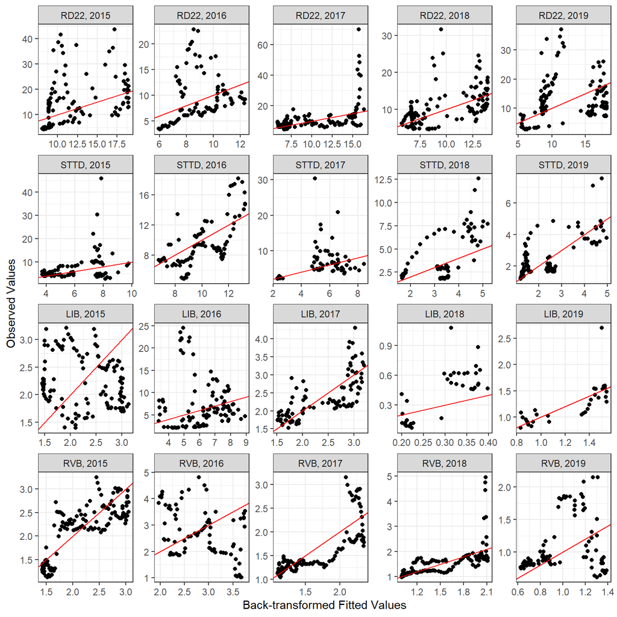

```r
plt_gamm3_ar1_obs_fit +
  facet_wrap(
    vars(StationCode, Year_fct),
    ncol = 5,
    scales = "free",
    labeller = labeller(.multi_line = FALSE)
  )
```

The red lines are the 1:1 ratio between fitted and observed values, and we would expect for most of the points to be near this line if the model has a good fit to the observed data. However, the fitted values from the model don’t appear to match the observed values that well, and there are some unusual patterns when we look at each Station-Year combination separately. I don’t think this GAM model is a good candidate to use for our analysis.

# Linear Model with 3-way interactions

Since the GAM model didn’t seem to fit the observed data that well, let’s try a linear model using a three-way interaction between Year, Daily Average Flow, and Station. Initially, we’ll run the model without accounting for serial autocorrelation.

## Initial Model

```r
m_lm3 <- df_chla_c2_lag %>%
  drop_na(Chla_log) %>%
  lm(Chla_log ~ Year_fct * Flow * StationCode, data = .)
```

Lets look at the model summary and diagnostics:

```r
summary(m_lm3)
```

```
##
## Call:
## lm(formula = Chla_log ~ Year_fct * Flow * StationCode, data = .)
##
## Residuals:
##      Min       1Q   Median       3Q      Max
## -1.53824 -0.22584 -0.03527  0.19362  1.75991
##
## Coefficients:
##                                     Estimate Std. Error t value Pr(>|t|)
## (Intercept)                        9.6844243  0.0452509 214.016  < 2e-16 ***
## Year_fct2016                      -0.6624673  0.0679526  -9.749  < 2e-16 ***
## Year_fct2017                      -1.1724759  0.0999868 -11.726  < 2e-16 ***
## Year_fct2018                      -0.3418296  0.0613064  -5.576 2.82e-08 ***
## Year_fct2019                      -0.1194239  0.0606175  -1.970 0.048971 *
## Flow                              -0.0018894  0.0001902  -9.935  < 2e-16 ***
## StationCodeSTTD                   -1.0665077  0.0583396 -18.281  < 2e-16 ***
## StationCodeLIB                    -2.2759582  0.1501355 -15.159  < 2e-16 ***
## StationCodeRVB                    -2.2211596  0.1087675 -20.421  < 2e-16 ***
## Year_fct2016:Flow                  0.0023191  0.0003112   7.451 1.40e-13 ***
## Year_fct2017:Flow                  0.0459260  0.0050786   9.043  < 2e-16 ***
## Year_fct2018:Flow                  0.0003299  0.0002697   1.223 0.221489
## Year_fct2019:Flow                 -0.0001500  0.0002357  -0.636 0.524638
## Year_fct2016:StationCodeSTTD       1.0883876  0.0888628  12.248  < 2e-16 ***
## Year_fct2017:StationCodeSTTD       1.4828385  0.1306889  11.346  < 2e-16 ***
## Year_fct2018:StationCodeSTTD      -0.3044581  0.0836642  -3.639 0.000281 ***
## Year_fct2019:StationCodeSTTD      -0.9412845  0.0821169 -11.463  < 2e-16 ***
## Year_fct2016:StationCodeLIB        2.0498183  0.2674351   7.665 2.85e-14 ***
## Year_fct2017:StationCodeLIB        1.3182346  0.2107896   6.254 4.95e-10 ***
## Year_fct2018:StationCodeLIB       -1.4934167  0.2582457  -5.783 8.58e-09 ***
## Year_fct2019:StationCodeLIB       -0.3466158  0.2273610  -1.525 0.127548
## Year_fct2016:StationCodeRVB        1.9708585  0.2227786   8.847  < 2e-16 ***
## Year_fct2017:StationCodeRVB        1.4604311  0.2117602   6.897 7.25e-12 ***
## Year_fct2018:StationCodeRVB       -0.0019108  0.1643456  -0.012 0.990725
## Year_fct2019:StationCodeRVB       -0.7693190  0.1962948  -3.919 9.20e-05 ***
## Flow:StationCodeSTTD               0.0046051  0.0003182  14.474  < 2e-16 ***
## Flow:StationCodeLIB                0.0017121  0.0002100   8.153 6.42e-16 ***
## Flow:StationCodeRVB                0.0019282  0.0001915  10.070  < 2e-16 ***
## Year_fct2016:Flow:StationCodeSTTD -0.0037137  0.0004737  -7.840 7.46e-15 ***
## Year_fct2017:Flow:StationCodeSTTD -0.0407758  0.0055375  -7.364 2.66e-13 ***
## Year_fct2018:Flow:StationCodeSTTD -0.0007383  0.0004198  -1.759 0.078768 .
## Year_fct2019:Flow:StationCodeSTTD -0.0012540  0.0003732  -3.360 0.000794 ***
## Year_fct2016:Flow:StationCodeLIB  -0.0020650  0.0003575  -5.777 8.89e-09 ***
## Year_fct2017:Flow:StationCodeLIB  -0.0459271  0.0050805  -9.040  < 2e-16 ***
## Year_fct2018:Flow:StationCodeLIB  -0.0004184  0.0004122  -1.015 0.310185
## Year_fct2019:Flow:StationCodeLIB   0.0001287  0.0003310   0.389 0.697449
## Year_fct2016:Flow:StationCodeRVB  -0.0024657  0.0003128  -7.884 5.33e-15 ***
## Year_fct2017:Flow:StationCodeRVB  -0.0460030  0.0050786  -9.058  < 2e-16 ***
## Year_fct2018:Flow:StationCodeRVB  -0.0003456  0.0002710  -1.275 0.202416
## Year_fct2019:Flow:StationCodeRVB   0.0001493  0.0002375   0.629 0.529618
## ---
## Signif. codes:  0 '***' 0.001 '**' 0.01 '*' 0.05 '.' 0.1 ' ' 1
##
## Residual standard error: 0.378 on 1881 degrees of freedom
## Multiple R-squared:  0.8556, Adjusted R-squared:  0.8526
## F-statistic: 285.8 on 39 and 1881 DF,  p-value: < 2.2e-16
```

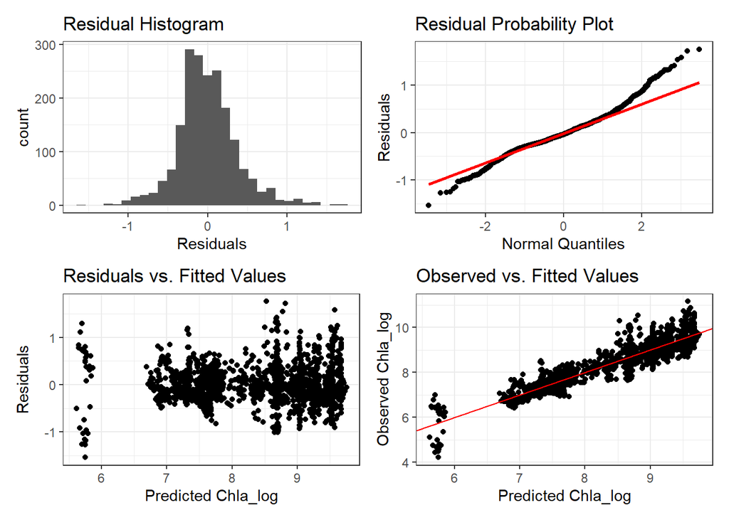

```r
df_chla_c2_lag %>%
  drop_na(Chla_log) %>%
  plot_lm_diag(Chla_log, m_lm3)
```

```r
shapiro.test(residuals(m_lm3))
```

```
##
##  Shapiro-Wilk normality test
##
## data:  residuals(m_lm3)
## W = 0.96994, p-value < 2.2e-16
```

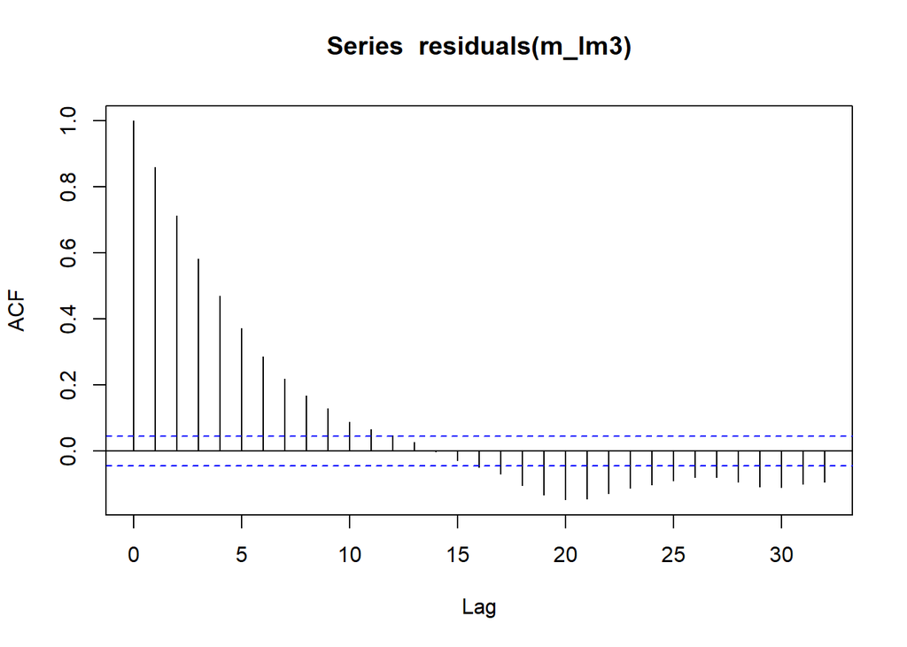

```r
acf(residuals(m_lm3))
```

```r
Box.test(residuals(m_lm3), lag = 20, type = 'Ljung-Box')
```

```
##
##  Box-Ljung test
##
## data:  residuals(m_lm3)
## X-squared = 4218.2, df = 20, p-value < 2.2e-16
```

The residuals deviate from a normal distribution according to visual inspection and the Shapiro-Wilk normality test. Also, model definitely has residual autocorrelation as indicated by the ACF plot and the Box-Ljung test.

### Model with lag terms

Now, we’ll try to deal with the residual autocorrelation and the non-normal residuals. We’ll run a series of linear models adding 1, 2, and 3 lag terms and compare how well they correct for autocorrelation.

#### Lag 1

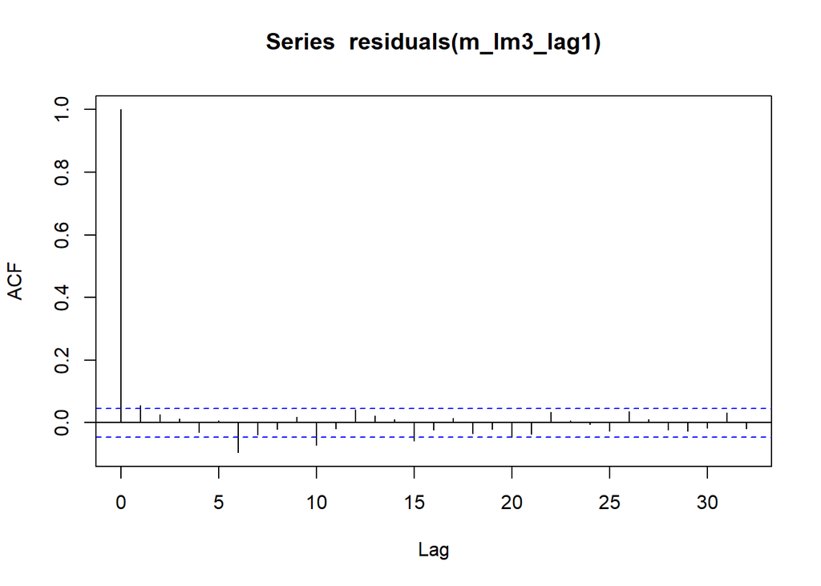

```r
m_lm3_lag1 <- df_chla_c2_lag %>%
  drop_na(Chla_log, lag1) %>%
  lm(Chla_log ~ Year_fct * Flow * StationCode + lag1, data = .)

acf(residuals(m_lm3_lag1))
```

```r
Box.test(residuals(m_lm3_lag1), lag = 20, type = 'Ljung-Box')
```

```
##
##  Box-Ljung test
##
## data:  residuals(m_lm3_lag1)
## X-squared = 59.583, df = 20, p-value = 8.262e-06
```

#### Lag 2

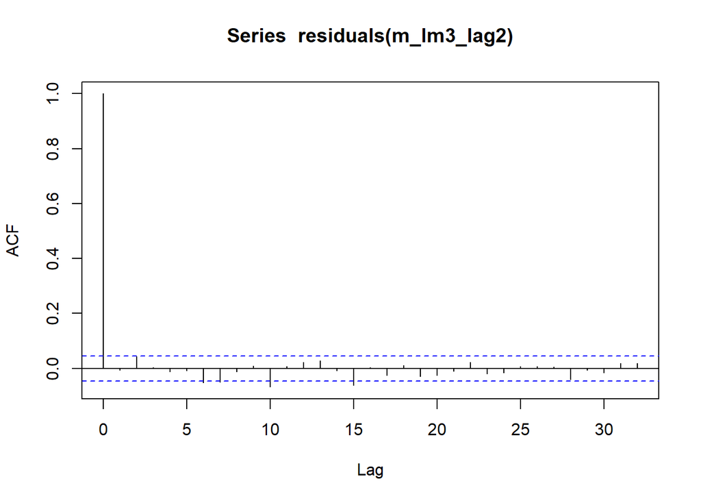

```r
m_lm3_lag2 <- df_chla_c2_lag %>%
  drop_na(Chla_log, lag1, lag2) %>%
  lm(Chla_log ~ Year_fct * Flow * StationCode + lag1 + lag2, data = .)

acf(residuals(m_lm3_lag2))
```

```r
Box.test(residuals(m_lm3_lag2), lag = 20, type = 'Ljung-Box')
```

```
##
##  Box-Ljung test
##
## data:  residuals(m_lm3_lag2)
## X-squared = 36.166, df = 20, p-value = 0.01471
```

#### Lag 3

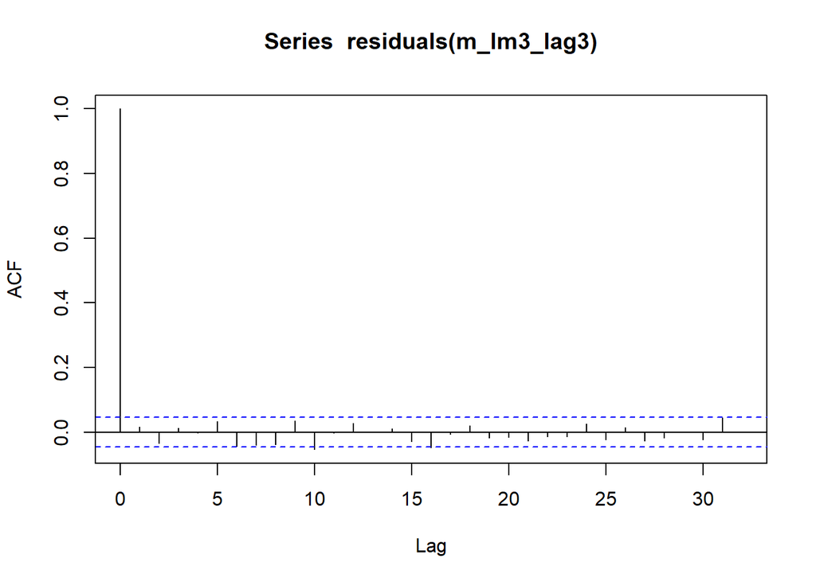

```r
m_lm3_lag3 <- df_chla_c2_lag %>%
  drop_na(Chla_log, lag1, lag2, lag3) %>%
  lm(Chla_log ~ Year_fct * Flow * StationCode + lag1 + lag2 + lag3, data = .)

acf(residuals(m_lm3_lag3))
```

```r
Box.test(residuals(m_lm3_lag3), lag = 20, type = 'Ljung-Box')
```

```
##
##  Box-Ljung test
##
## data:  residuals(m_lm3_lag3)
## X-squared = 29.8, df = 20, p-value = 0.07317
```

The model with 3 lag terms looks to have slightly better ACF and Box-Ljung test results than the other models. Let’s compare the 3 models using AIC and BIC to see which model those prefer.

#### Compare models

```r
AIC(m_lm3_lag1, m_lm3_lag2, m_lm3_lag3)
```

```
##            df       AIC
## m_lm3_lag1 42 -1332.474
## m_lm3_lag2 43 -1320.991
## m_lm3_lag3 44 -1301.195
```

```r
BIC(m_lm3_lag1, m_lm3_lag2, m_lm3_lag3)
```

```
##            df       BIC
## m_lm3_lag1 42 -1099.969
## m_lm3_lag2 43 -1083.949
## m_lm3_lag3 44 -1059.514
```

Both AIC and BIC prefer the model with 1 lag term. Let’s take a closer look at that one.

### Lag 1 model summary

```r
summary(m_lm3_lag1)
```

```
##
## Call:
## lm(formula = Chla_log ~ Year_fct * Flow * StationCode + lag1,
##     data = .)
##
## Residuals:
##      Min       1Q   Median       3Q      Max
## -1.11307 -0.05814 -0.00595  0.05217  1.06385
##
## Coefficients:
##                                     Estimate Std. Error t value Pr(>|t|)
## (Intercept)                        1.001e+00  1.029e-01   9.728  < 2e-16 ***
## Year_fct2016                      -9.809e-02  3.103e-02  -3.161 0.001598 **
## Year_fct2017                      -1.525e-01  4.616e-02  -3.303 0.000975 ***
## Year_fct2018                      -5.790e-02  2.756e-02  -2.101 0.035792 *
## Year_fct2019                      -2.174e-02  2.708e-02  -0.803 0.422137
## Flow                              -3.367e-04  8.645e-05  -3.895 0.000102 ***
## StationCodeSTTD                   -1.182e-01  2.830e-02  -4.177 3.10e-05 ***
## StationCodeLIB                    -1.924e-01  7.091e-02  -2.713 0.006729 **
## StationCodeRVB                    -2.181e-01  5.374e-02  -4.059 5.14e-05 ***
## lag1                               8.985e-01  1.044e-02  86.090  < 2e-16 ***
## Year_fct2016:Flow                  3.634e-04  1.401e-04   2.594 0.009552 **
## Year_fct2017:Flow                  5.522e-03  2.327e-03   2.373 0.017739 *
## Year_fct2018:Flow                  2.083e-04  1.199e-04   1.738 0.082447 .
## Year_fct2019:Flow                  1.407e-04  1.048e-04   1.342 0.179847
## Year_fct2016:StationCodeSTTD       1.270e-01  4.128e-02   3.078 0.002115 **
## Year_fct2017:StationCodeSTTD       2.685e-01  6.059e-02   4.432 9.90e-06 ***
## Year_fct2018:StationCodeSTTD      -1.769e-02  3.753e-02  -0.471 0.637527
## Year_fct2019:StationCodeSTTD      -9.963e-02  3.804e-02  -2.619 0.008883 **
## Year_fct2016:StationCodeLIB        2.879e-01  1.205e-01   2.388 0.017030 *
## Year_fct2017:StationCodeLIB        1.367e-01  9.785e-02   1.397 0.162477
## Year_fct2018:StationCodeLIB       -1.636e-01  1.329e-01  -1.231 0.218468
## Year_fct2019:StationCodeLIB       -2.590e-02  1.048e-01  -0.247 0.804794
## Year_fct2016:StationCodeRVB        2.448e-01  1.028e-01   2.382 0.017302 *
## Year_fct2017:StationCodeRVB        1.841e-01  9.545e-02   1.929 0.053871 .
## Year_fct2018:StationCodeRVB        3.772e-02  7.309e-02   0.516 0.605905
## Year_fct2019:StationCodeRVB       -3.273e-02  8.873e-02  -0.369 0.712219
## Flow:StationCodeSTTD               6.188e-04  1.508e-04   4.103 4.26e-05 ***
## Flow:StationCodeLIB                3.573e-04  9.469e-05   3.774 0.000166 ***
## Flow:StationCodeRVB                3.341e-04  8.712e-05   3.835 0.000130 ***
## Year_fct2016:Flow:StationCodeSTTD -5.296e-04  2.150e-04  -2.463 0.013871 *
## Year_fct2017:Flow:StationCodeSTTD -2.463e-03  2.544e-03  -0.968 0.333192
## Year_fct2018:Flow:StationCodeSTTD -2.088e-04  1.882e-04  -1.109 0.267388
## Year_fct2019:Flow:StationCodeSTTD -2.486e-04  1.680e-04  -1.480 0.139048
## Year_fct2016:Flow:StationCodeLIB  -2.807e-04  1.601e-04  -1.753 0.079803 .
## Year_fct2017:Flow:StationCodeLIB  -5.534e-03  2.328e-03  -2.377 0.017554 *
## Year_fct2018:Flow:StationCodeLIB  -1.611e-04  2.125e-04  -0.758 0.448487
## Year_fct2019:Flow:StationCodeLIB  -1.318e-04  1.537e-04  -0.857 0.391346
## Year_fct2016:Flow:StationCodeRVB  -3.780e-04  1.410e-04  -2.681 0.007399 **
## Year_fct2017:Flow:StationCodeRVB  -5.527e-03  2.327e-03  -2.375 0.017656 *
## Year_fct2018:Flow:StationCodeRVB  -2.086e-04  1.205e-04  -1.732 0.083497 .
## Year_fct2019:Flow:StationCodeRVB  -1.420e-04  1.056e-04  -1.345 0.178840
## ---
## Signif. codes:  0 '***' 0.001 '**' 0.01 '*' 0.05 '.' 0.1 ' ' 1
##
## Residual standard error: 0.1677 on 1833 degrees of freedom
## Multiple R-squared:  0.9709, Adjusted R-squared:  0.9703
## F-statistic:  1531 on 40 and 1833 DF,  p-value: < 2.2e-16
```

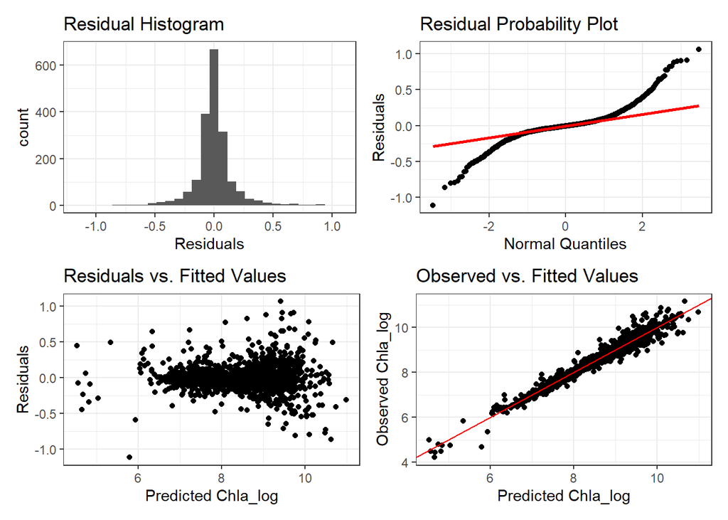

```r
df_chla_c2_lag %>%
  drop_na(Chla_log, lag1) %>%
  plot_lm_diag(Chla_log, m_lm3_lag1)
```

```r
shapiro.test(residuals(m_lm3_lag1))
```

```
##
##  Shapiro-Wilk normality test
##
## data:  residuals(m_lm3_lag1)
## W = 0.86196, p-value < 2.2e-16
```

The residuals deviate from a normal distribution particularly at the both tails of the distribution. I’m not so sure about using this model. Let’s take a closer look at how the back-transformed fitted values from the model match the observed values.

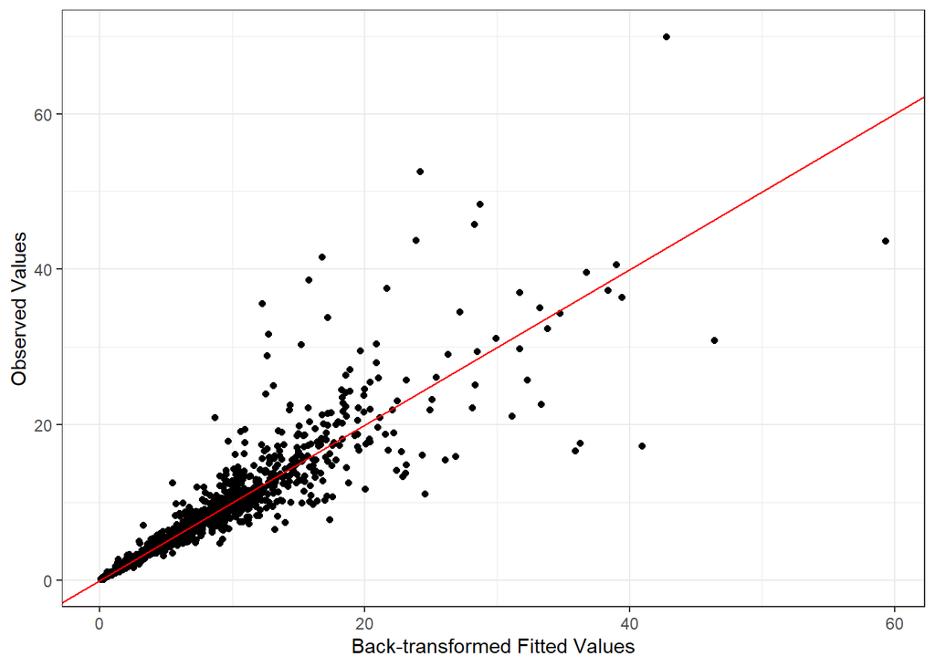

```r
df_lm3_lag1_fit <- df_chla_c2_lag %>%
  drop_na(Chla, lag1) %>%
  mutate(Fitted = as_tibble(predict(m_lm3_lag1, interval = "confidence"))) %>%
  unnest_wider(Fitted) %>%
  mutate(across(c("fit", "lwr", "upr"), ~ exp(.x) / 1000))

plt_lm3_lag1_obs_fit <- df_lm3_lag1_fit %>%
  ggplot(aes(x = fit, y = Chla)) +
  geom_point() +
  geom_abline(slope = 1, intercept = 0, color = "red") +
  theme_bw() +
  labs(
    x = "Back-transformed Fitted Values",
    y = "Observed Values"
  )

plt_lm3_lag1_obs_fit
```

Let’s look at each Station-Year combination separately.

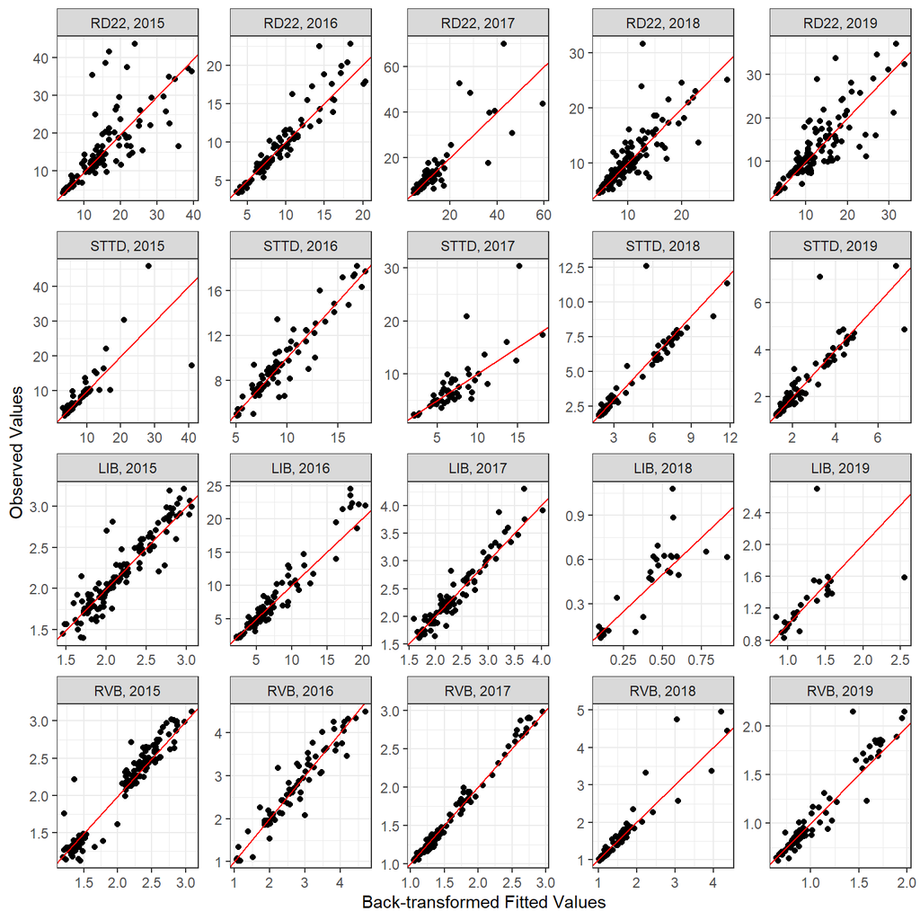

```r
plt_lm3_lag1_obs_fit +
  facet_wrap(
    vars(StationCode, Year_fct),
    ncol = 5,
    scales = "free",
    labeller = labeller(.multi_line = FALSE)
  )
```

The red lines are the 1:1 ratio between fitted and observed values, and we would expect for most of the points to be near this line if the model has a good fit to the observed data. The fitted and observed values appear to match pretty well at the lower end of the range of values, but this deteriorates at the mid and higher range values. This pattern holds for some of the separate Station-Year combinations. I’m not sure this linear model is a good candidate to use for our analysis.

### Lag 3 model summary

Let’s take a closer look at the model with 3 lag terms since that had the least autocorrelation.

```r
summary(m_lm3_lag3)
```

```
##
## Call:
## lm(formula = Chla_log ~ Year_fct * Flow * StationCode + lag1 +
##     lag2 + lag3, data = .)
##
## Residuals:
##      Min       1Q   Median       3Q      Max
## -1.10205 -0.05729 -0.00689  0.05130  1.10315
##
## Coefficients:
##                                     Estimate Std. Error t value Pr(>|t|)
## (Intercept)                        1.157e+00  1.107e-01  10.454  < 2e-16 ***
## Year_fct2016                      -9.661e-02  3.126e-02  -3.091 0.002027 **
## Year_fct2017                      -1.610e-01  4.643e-02  -3.467 0.000540 ***
## Year_fct2018                      -5.585e-02  2.771e-02  -2.016 0.043975 *
## Year_fct2019                      -1.043e-02  2.720e-02  -0.383 0.701433
## Flow                              -3.249e-04  8.626e-05  -3.766 0.000171 ***
## StationCodeSTTD                   -1.216e-01  2.874e-02  -4.232 2.43e-05 ***
## StationCodeLIB                    -2.218e-01  7.148e-02  -3.102 0.001950 **
## StationCodeRVB                    -2.404e-01  5.410e-02  -4.444 9.37e-06 ***
## lag1                               9.520e-01  2.404e-02  39.604  < 2e-16 ***
## lag2                              -6.912e-03  3.300e-02  -0.209 0.834141
## lag3                              -6.404e-02  2.396e-02  -2.672 0.007602 **
## Year_fct2016:Flow                  3.667e-04  1.395e-04   2.629 0.008641 **
## Year_fct2017:Flow                  6.434e-03  2.364e-03   2.722 0.006556 **
## Year_fct2018:Flow                  1.808e-04  1.194e-04   1.514 0.130087
## Year_fct2019:Flow                  9.141e-05  1.045e-04   0.875 0.381899
## Year_fct2016:StationCodeSTTD       1.392e-01  4.182e-02   3.329 0.000889 ***
## Year_fct2017:StationCodeSTTD       2.677e-01  6.087e-02   4.399 1.15e-05 ***
## Year_fct2018:StationCodeSTTD      -3.326e-02  3.782e-02  -0.880 0.379189
## Year_fct2019:StationCodeSTTD      -1.314e-01  3.855e-02  -3.408 0.000669 ***
## Year_fct2016:StationCodeLIB        2.940e-01  1.214e-01   2.422 0.015517 *
## Year_fct2017:StationCodeLIB        1.346e-01  1.007e-01   1.337 0.181412
## Year_fct2018:StationCodeLIB       -2.818e-01  1.426e-01  -1.976 0.048279 *
## Year_fct2019:StationCodeLIB       -6.092e-02  1.303e-01  -0.467 0.640243
## Year_fct2016:StationCodeRVB        2.601e-01  1.100e-01   2.364 0.018204 *
## Year_fct2017:StationCodeRVB        1.906e-01  9.562e-02   1.993 0.046416 *
## Year_fct2018:StationCodeRVB        2.043e-02  7.272e-02   0.281 0.778735
## Year_fct2019:StationCodeRVB       -1.232e-01  9.296e-02  -1.326 0.185077
## Flow:StationCodeSTTD               6.575e-04  1.545e-04   4.254 2.21e-05 ***
## Flow:StationCodeLIB                3.407e-04  9.466e-05   3.599 0.000328 ***
## Flow:StationCodeRVB                3.220e-04  8.693e-05   3.704 0.000219 ***
## Year_fct2016:Flow:StationCodeSTTD -5.712e-04  2.169e-04  -2.633 0.008528 **
## Year_fct2017:Flow:StationCodeSTTD -3.888e-03  2.608e-03  -1.491 0.136168
## Year_fct2018:Flow:StationCodeSTTD -2.004e-04  1.903e-04  -1.053 0.292443
## Year_fct2019:Flow:StationCodeSTTD -2.358e-04  1.704e-04  -1.384 0.166560
## Year_fct2016:Flow:StationCodeLIB  -2.891e-04  1.602e-04  -1.805 0.071255 .
## Year_fct2017:Flow:StationCodeLIB  -6.458e-03  2.365e-03  -2.731 0.006386 **
## Year_fct2018:Flow:StationCodeLIB  -2.967e-04  2.335e-04  -1.271 0.203981
## Year_fct2019:Flow:StationCodeLIB  -1.055e-04  1.901e-04  -0.555 0.578996
## Year_fct2016:Flow:StationCodeRVB  -3.828e-04  1.405e-04  -2.725 0.006496 **
## Year_fct2017:Flow:StationCodeRVB  -6.439e-03  2.364e-03  -2.724 0.006523 **
## Year_fct2018:Flow:StationCodeRVB  -1.798e-04  1.200e-04  -1.498 0.134302
## Year_fct2019:Flow:StationCodeRVB  -8.592e-05  1.054e-04  -0.816 0.414863
## ---
## Signif. codes:  0 '***' 0.001 '**' 0.01 '*' 0.05 '.' 0.1 ' ' 1
##
## Residual standard error: 0.1663 on 1752 degrees of freedom
## Multiple R-squared:  0.9706, Adjusted R-squared:  0.9699
## F-statistic:  1378 on 42 and 1752 DF,  p-value: < 2.2e-16
```

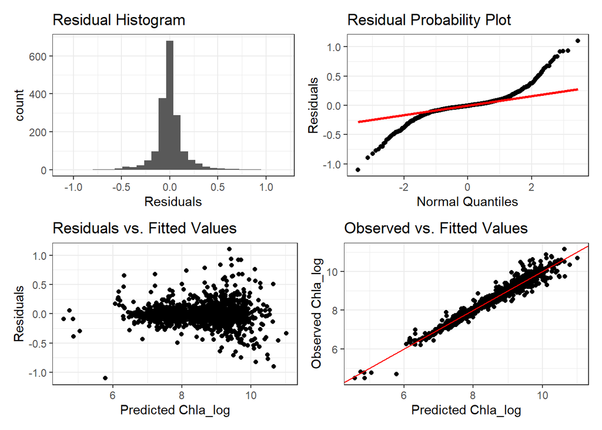

```r
df_chla_c2_lag %>%
  drop_na(Chla_log, lag1, lag2, lag3) %>%
  plot_lm_diag(Chla_log, m_lm3_lag3)
```

```r
shapiro.test(residuals(m_lm3_lag3))
```

```
##
##  Shapiro-Wilk normality test
##
## data:  residuals(m_lm3_lag3)
## W = 0.8528, p-value < 2.2e-16
```

The diagnostic plots show that the lag 3 model has similar problems as the lag 1 model, so this doesn’t look like a good candidate for our analysis as well.

# GAM Model with 2-way interactions

Because the models using 3-way interactions don’t seem to fit the data well, we will attempt to fit a generalized additive model (GAM) to the data set using all two-way interactions between Year, Daily Average Flow, and Station, with a smooth term for day of year to account for seasonality. Initially, we’ll run the GAM without accounting for serial autocorrelation.

## Initial Model

```r
m_gam2 <- gam(
  Chla_log ~ (Year_fct + Flow + StationCode)^2 + s(DOY, k = 5),
  data = df_chla_c2,
  method = "REML"
)
```

Lets look at the model summary and diagnostics:

```r
summary(m_gam2)
```

```
##
## Family: gaussian
## Link function: identity
##
## Formula:
## Chla_log ~ (Year_fct + Flow + StationCode)^2 + s(DOY, k = 5)
##
## Parametric coefficients:
##                                Estimate Std. Error t value Pr(>|t|)
## (Intercept)                   9.688e+00  3.752e-02 258.201  < 2e-16 ***
## Year_fct2016                 -5.462e-01  5.415e-02 -10.087  < 2e-16 ***
## Year_fct2017                 -3.975e-01  5.038e-02  -7.891 5.02e-15 ***
## Year_fct2018                 -3.166e-01  4.815e-02  -6.576 6.24e-11 ***
## Year_fct2019                 -1.727e-01  4.848e-02  -3.562 0.000377 ***
## Flow                         -1.460e-03  9.154e-05 -15.953  < 2e-16 ***
## StationCodeSTTD              -9.919e-01  5.113e-02 -19.400  < 2e-16 ***
## StationCodeLIB               -1.930e+00  1.079e-01 -17.897  < 2e-16 ***
## StationCodeRVB               -2.140e+00  9.850e-02 -21.721  < 2e-16 ***
## Year_fct2016:Flow            -4.570e-05  3.126e-05  -1.462 0.143979
## Year_fct2017:Flow            -4.495e-05  2.527e-05  -1.779 0.075411 .
## Year_fct2018:Flow            -1.826e-05  2.555e-05  -0.715 0.474786
## Year_fct2019:Flow             4.051e-06  2.720e-05   0.149 0.881632
## Year_fct2016:StationCodeSTTD  7.454e-01  7.498e-02   9.941  < 2e-16 ***
## Year_fct2017:StationCodeSTTD  3.922e-01  7.886e-02   4.974 7.16e-07 ***
## Year_fct2018:StationCodeSTTD -3.423e-01  7.218e-02  -4.743 2.26e-06 ***
## Year_fct2019:StationCodeSTTD -9.528e-01  7.064e-02 -13.488  < 2e-16 ***
## Year_fct2016:StationCodeLIB   1.293e+00  8.638e-02  14.969  < 2e-16 ***
## Year_fct2017:StationCodeLIB   3.824e-01  8.524e-02   4.487 7.66e-06 ***
## Year_fct2018:StationCodeLIB  -1.577e+00  1.060e-01 -14.875  < 2e-16 ***
## Year_fct2019:StationCodeLIB  -5.273e-01  1.082e-01  -4.875 1.18e-06 ***
## Year_fct2016:StationCodeRVB   8.304e-01  2.334e-01   3.557 0.000384 ***
## Year_fct2017:StationCodeRVB   4.753e-01  1.859e-01   2.556 0.010665 *
## Year_fct2018:StationCodeRVB   7.054e-02  1.538e-01   0.459 0.646619
## Year_fct2019:StationCodeRVB  -6.698e-01  1.828e-01  -3.664 0.000255 ***
## Flow:StationCodeSTTD          3.336e-03  1.263e-04  26.406  < 2e-16 ***
## Flow:StationCodeLIB           1.501e-03  1.106e-04  13.572  < 2e-16 ***
## Flow:StationCodeRVB           1.483e-03  9.028e-05  16.427  < 2e-16 ***
## ---
## Signif. codes:  0 '***' 0.001 '**' 0.01 '*' 0.05 '.' 0.1 ' ' 1
##
## Approximate significance of smooth terms:
##          edf Ref.df     F p-value
## s(DOY) 3.883  3.992 93.07  <2e-16 ***
## ---
## Signif. codes:  0 '***' 0.001 '**' 0.01 '*' 0.05 '.' 0.1 ' ' 1
##
## R-sq.(adj) =  0.863   Deviance explained = 86.5%
## -REML = 906.44  Scale est. = 0.13309   n = 1921
```

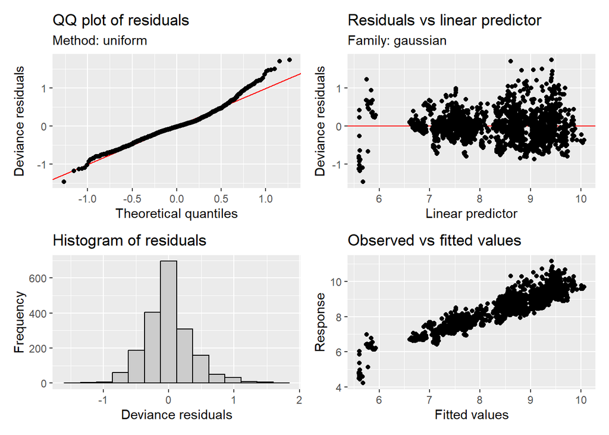

```r
appraise(m_gam2)
```

```r
shapiro.test(residuals(m_gam2))
```

```
##
##  Shapiro-Wilk normality test
##
## data:  residuals(m_gam2)
## W = 0.97201, p-value < 2.2e-16
```

```r
k.check(m_gam2)
```

```
##        k'      edf   k-index p-value
## s(DOY)  4 3.883314 0.9303233       0
```

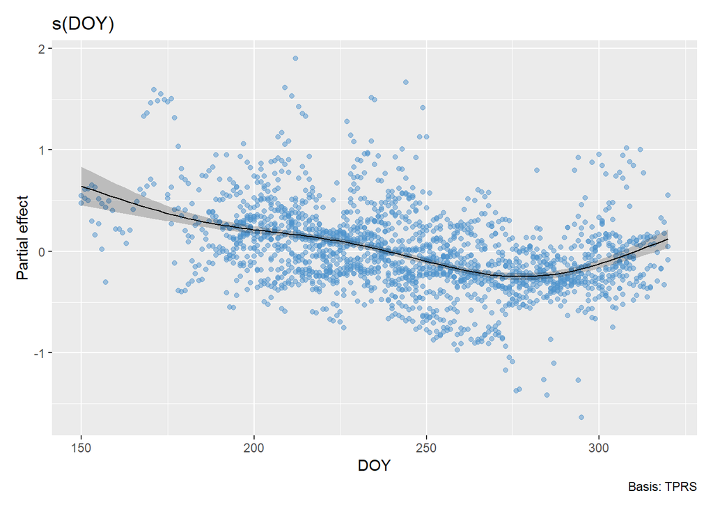

```r
draw(m_gam2, select = 1, residuals = TRUE, rug = FALSE)
```

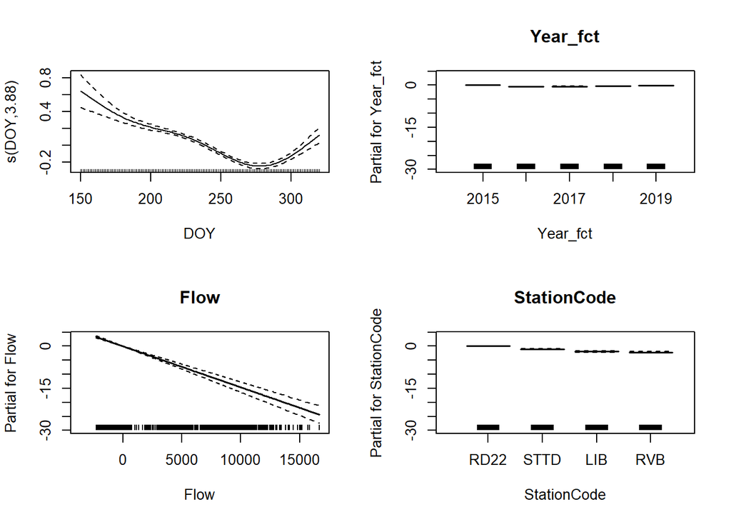

```r
plot(m_gam2, pages = 1, all.terms = TRUE)
```

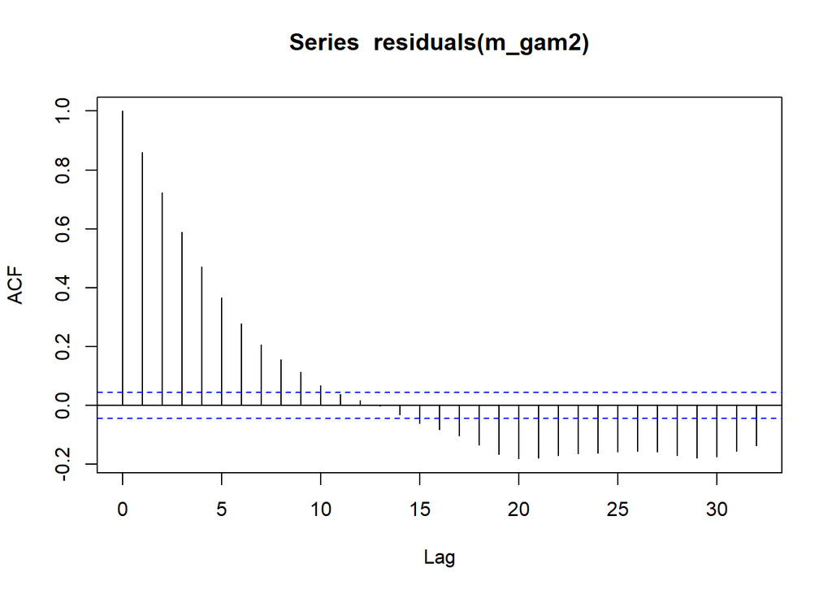

```r
acf(residuals(m_gam2))
```

```r
Box.test(residuals(m_gam2), lag = 20, type = 'Ljung-Box')
```

```
##
##  Box-Ljung test
##
## data:  residuals(m_gam2)
## X-squared = 4292.7, df = 20, p-value < 2.2e-16
```

## Model with AR() correlation structure

Now, we’ll try to deal with the residual autocorrelation. We’ll run AR(1), AR(2), AR(3), and AR(4) models and compare them using AIC.

```r
# Define model formula as an object
f_gam2 <- as.formula("Chla_log ~ (Year_fct + Flow + StationCode)^2 + s(DOY, k = 5)")

# Fit original model with k = 5 and three successive AR(p) models
m_gamm2 <- gamm(
  f_gam2,
  data = df_chla_c2,
  method = "REML"
)

m_gamm2_ar1 <- gamm(
  f_gam2,
  data = df_chla_c2,
  correlation = corARMA(form = ~ 1|Year_fct/StationCode, p = 1), # grouped by Year_fct and StationCode
  method = "REML"
)

m_gamm2_ar2 <- gamm(
  f_gam2,
  data = df_chla_c2,
  correlation = corARMA(form = ~ 1|Year_fct/StationCode, p = 2),
  method = "REML"
)

m_gamm2_ar3 <- gamm(
  f_gam2,
  data = df_chla_c2,
  correlation = corARMA(form = ~ 1|Year_fct/StationCode, p = 3),
  method = "REML"
)

m_gamm2_ar4 <- gamm(
  f_gam2,
  data = df_chla_c2,
  correlation = corARMA(form = ~ 1|Year_fct/StationCode, p = 4),
  method = "REML"
)

# Compare models
anova(
  m_gamm2$lme,
  m_gamm2_ar1$lme,
  m_gamm2_ar2$lme,
  m_gamm2_ar3$lme,
  m_gamm2_ar4$lme
)
```

```
##                 Model df       AIC       BIC    logLik   Test   L.Ratio p-value
## m_gamm2$lme         1 31 1874.8752 2046.7822 -906.4376
## m_gamm2_ar1$lme     2 32 -917.8475 -740.3950  490.9238 1 vs 2 2794.7227  <.0001
## m_gamm2_ar2$lme     3 33 -916.3375 -733.3396  491.1687 2 vs 3    0.4900  0.4839
## m_gamm2_ar3$lme     4 34 -917.2007 -728.6574  492.6003 3 vs 4    2.8632  0.0906
## m_gamm2_ar4$lme     5 35 -915.4855 -721.3969  492.7428 4 vs 5    0.2848  0.5936
```

It looks like the AR(1) model has the best fit according to the AIC and BIC values. Let’s take a closer look at the AR(1) model.

## AR(1) Model

```r
# Pull out the residuals and the GAM model
resid_gamm2_ar1 <- residuals(m_gamm2_ar1$lme, type = "normalized")
m_gamm2_ar1_gam <- m_gamm2_ar1$gam

summary(m_gamm2_ar1_gam)
```

```
##
## Family: gaussian
## Link function: identity
##
## Formula:
## Chla_log ~ (Year_fct + Flow + StationCode)^2 + s(DOY, k = 5)
##
## Parametric coefficients:
##                                Estimate Std. Error t value Pr(>|t|)
## (Intercept)                   9.499e+00  2.554e-01  37.194  < 2e-16 ***
## Year_fct2016                 -5.044e-01  3.805e-01  -1.325 0.185176
## Year_fct2017                 -2.380e-01  3.574e-01  -0.666 0.505493
## Year_fct2018                 -2.842e-01  3.516e-01  -0.808 0.418971
## Year_fct2019                 -4.756e-02  3.534e-01  -0.135 0.892969
## Flow                         -5.814e-04  1.880e-04  -3.093 0.002013 **
## StationCodeSTTD              -7.963e-01  3.606e-01  -2.208 0.027339 *
## StationCodeLIB               -1.541e+00  3.567e-01  -4.320 1.64e-05 ***
## StationCodeRVB               -1.802e+00  3.510e-01  -5.133 3.14e-07 ***
## Year_fct2016:Flow            -9.464e-06  2.004e-05  -0.472 0.636788
## Year_fct2017:Flow            -2.725e-06  2.032e-05  -0.134 0.893321
## Year_fct2018:Flow            -5.029e-06  2.185e-05  -0.230 0.818003
## Year_fct2019:Flow            -2.100e-05  2.047e-05  -1.026 0.304988
## Year_fct2016:StationCodeSTTD  8.188e-01  5.352e-01   1.530 0.126195
## Year_fct2017:StationCodeSTTD -9.049e-02  5.460e-01  -0.166 0.868392
## Year_fct2018:StationCodeSTTD -4.750e-01  5.186e-01  -0.916 0.359835
## Year_fct2019:StationCodeSTTD -1.039e+00  5.094e-01  -2.039 0.041548 *
## Year_fct2016:StationCodeLIB   1.407e+00  5.202e-01   2.705 0.006900 **
## Year_fct2017:StationCodeLIB   1.655e-01  5.081e-01   0.326 0.744633
## Year_fct2018:StationCodeLIB  -1.832e+00  5.647e-01  -3.244 0.001197 **
## Year_fct2019:StationCodeLIB  -7.660e-01  5.742e-01  -1.334 0.182305
## Year_fct2016:StationCodeRVB   8.858e-01  5.518e-01   1.605 0.108565
## Year_fct2017:StationCodeRVB   1.627e-02  5.257e-01   0.031 0.975309
## Year_fct2018:StationCodeRVB  -3.484e-02  5.084e-01  -0.069 0.945361
## Year_fct2019:StationCodeRVB  -5.837e-01  5.181e-01  -1.127 0.260065
## Flow:StationCodeSTTD          1.710e-03  3.001e-04   5.698 1.40e-08 ***
## Flow:StationCodeLIB           7.500e-04  1.930e-04   3.885 0.000106 ***
## Flow:StationCodeRVB           5.801e-04  1.879e-04   3.087 0.002052 **
## ---
## Signif. codes:  0 '***' 0.001 '**' 0.01 '*' 0.05 '.' 0.1 ' ' 1
##
## Approximate significance of smooth terms:
##          edf Ref.df     F p-value
## s(DOY) 3.815  3.815 13.05  <2e-16 ***
## ---
## Signif. codes:  0 '***' 0.001 '**' 0.01 '*' 0.05 '.' 0.1 ' ' 1
##
## R-sq.(adj) =  0.787
##   Scale est. = 0.27723   n = 1921
```

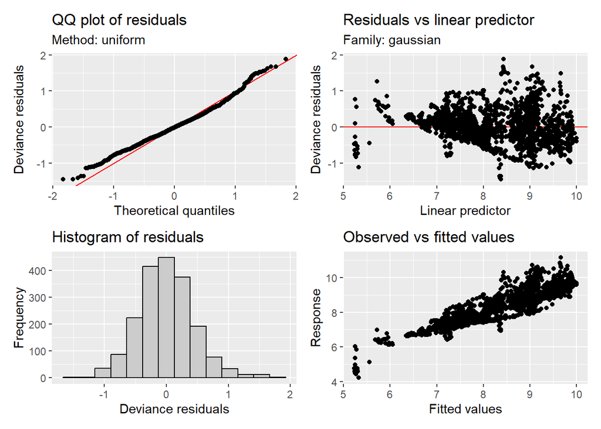

```r
appraise(m_gamm2_ar1_gam)
```

```r
shapiro.test(resid_gamm2_ar1)
```

```
##
##  Shapiro-Wilk normality test
##
## data:  resid_gamm2_ar1
## W = 0.82416, p-value < 2.2e-16
```

```r
k.check(m_gamm2_ar1_gam)
```

```
##        k'      edf   k-index p-value
## s(DOY)  4 3.814541 0.7173524       0
```

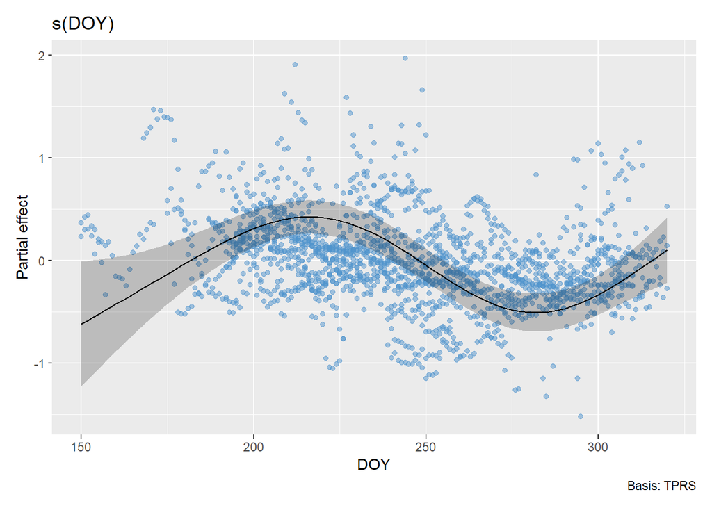

```r
draw(m_gamm2_ar1_gam, select = 1, residuals = TRUE, rug = FALSE)
```

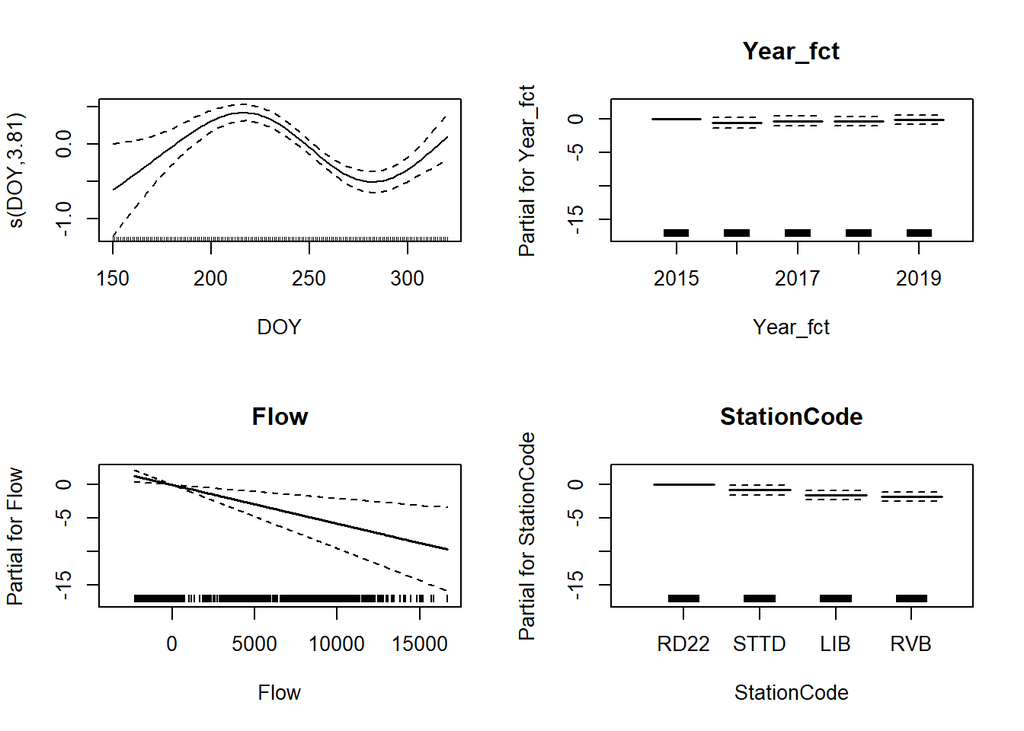

```r
plot(m_gamm2_ar1_gam, pages = 1, all.terms = TRUE)
```